# Taller Clase 23 — Series de tiempo

- Mostrar todo el código
- Ocultar todo el código
- Ver el código fuente

Series de Tiempo — Pregrado en Estadística, UNAL Medellín

Autores/as

Afiliación

Isabela Pulgarin Durango

Departamento de Estadística - UNALMED

Sebastián Valencia Botero

Fecha de publicación

26 de noviembre de 2026

# 1 Funciones

**Mostrar/ocultar código**

```r
# Cargar librerias
library(ggplot2)
library(patchwork)
```

**Mostrar/ocultar código**

```r
library(dplyr)
```

**Mostrar/ocultar código**

```r
library(forecast)
```

**Mostrar/ocultar código**

```r
library(urca)
```

**Mostrar/ocultar código**

```r
library(uroot)
library(knitr)
```

**Mostrar/ocultar código**

```r
# Leer serie
leer_serie <- function(x, col_fecha, col_valor, fuente, unidad) {

  datos <- read.csv(x)

  # Verificar que existan las columnas
  if (!all(c(col_fecha, col_valor) %in% names(datos))) {
    stop("Las columnas especificadas no existen en el CSV.")
  }

  # Convertir fechas según su formato
  fecha_original <- as.character(datos[[col_fecha]])

  if (all(grepl("^\\d{4}-\\d{2}$", fecha_original))) {

    # Formato mensual
    fecha <- as.Date(paste0(fecha_original, "-01"))
    frecuencia <- "mensual"

  } else if (all(grepl("^\\d{4}-T[1-4]$", fecha_original))) {

    # Formato trimestral
    anio <- as.integer(substr(fecha_original, 1, 4))
    trimestre <- as.integer(substr(fecha_original, 7, 7))

    mes <- c(1, 4, 7, 10)[trimestre]

    fecha <- as.Date(
      paste(anio, mes, "01", sep = "-")
    )

    frecuencia <- "trimestral"

  } else {

    stop("El formato de las fechas no es mensual ni trimestral")
  }

  # Convertir valores
  y <- as.numeric(datos[[col_valor]])

  # Verificaciones
  if (any(is.na(fecha))) {
    stop("Hay fechas inválidas en el CSV.")
  }

  if (any(is.na(y))) {
    stop("La serie contiene valores faltantes o no numéricos.")
  }

  if (length(y) < 2) {
    stop("Se necesitan al menos dos observaciones.")
  }

  if (any(diff(fecha) <= 0)) {
    stop("Las fechas deben estar en orden creciente y sin repetir.")
  }

  # Crear serie estandarizada
  resultado <- tibble::tibble(
    t = seq_along(y),
    fecha = fecha,
    y = y
  )

  # Guardar información adicional
  attr(resultado, "frecuencia") <- frecuencia
  attr(resultado, "fuente") <- fuente
  attr(resultado, "unidad") <- unidad

  return(resultado)
}
```

**Mostrar/ocultar código**

```r
# Gráfica de la serie, ACF y PACF
graficar_serie <- function(datos) {

  n <- nrow(datos)

  banda <- 1.96 / sqrt(n)

  # Serie
  p_serie <- ggplot(datos, aes(x = fecha, y = y)) +
    geom_line(color = "blue") +
    labs(
      x = "Fecha",
      y = "CO2 (ppm)"
    ) +
    theme_minimal()

  # ACF
  acf_obj <- acf(datos$y, plot = FALSE)

  acf_df <- data.frame(
    rezago = as.numeric(acf_obj$lag),
    acf = as.numeric(acf_obj$acf)
  )

  p_acf <- ggplot(acf_df, aes(x = rezago, y = acf)) +

    geom_hline(yintercept = 0) +

    geom_hline(
      yintercept = c(-banda, banda),
      linetype = "dashed",
      color = "purple"
    ) +

    geom_segment(
      aes(
        xend = rezago,
        yend = 0
      ),
      color = "blue"
    ) +

    labs(
      x = "Rezago",
      y = "ACF"
    ) +

    theme_minimal()

  # PACF
  pacf_obj <- pacf(datos$y, plot = FALSE)

  pacf_df <- data.frame(
    rezago = as.numeric(pacf_obj$lag),
    pacf = as.numeric(pacf_obj$acf)
  )

  p_pacf <- ggplot(pacf_df, aes(x = rezago, y = pacf)) +

    geom_hline(yintercept = 0) +

    geom_hline(
      yintercept = c(-banda, banda),
      linetype = "dashed",
      color = "purple"
    ) +

    geom_segment(
      aes(
        xend = rezago,
        yend = 0
      ),
      color = "blue"
    ) +

    labs(
      x = "Rezago",
      y = "PACF"
    ) +

    theme_minimal()


  figura <- p_serie +
    (p_acf / p_pacf) +
    plot_layout(
      widths = c(2, 1)
    )

  return(figura)
}
```

**Mostrar/ocultar código**

```r
#Perfil Box Cox
perfil_boxcox <- function(z, s = 12, graficar = TRUE) {

  n <- length(z)
  m <- n - s - 5

  z_media <- exp(mean(log(z)))
  lambdas <- round(seq(-2, 2, by = 0.01), 2)

  S <- sapply(lambdas, function(lambda) {
    if (abs(lambda) < 1e-10) {
      z_trans <- z_media * log(z)
  } else {
  z_trans <- (z^lambda - 1) /
    (lambda * z_media^(lambda - 1))
  }

    # Diferencia regular y estacional
    dz <- diff(diff(z_trans), lag = s)

    modelo <- arima(dz, order = c(4, 0, 0),
                    include.mean = TRUE, method = "CSS")

    # Solo los n* residuos del AR(4)
    sum(residuals(modelo)[-(1:4)]^2)
  })

  S_min      <- min(S)
  lambda_hat <- lambdas[which.min(S)]
  G          <- m * log(S / S_min)
  compatibles <- lambdas[G <= qchisq(0.95, 1)]

  if (graficar) {
    plot(lambdas, G, type = "l", col = "blue",
         xlab = expression(lambda), ylab = expression(G(lambda)),
         main = "Perfil de Box y Cox")
    abline(h = qchisq(0.95, 1), lty = 2)
    abline(v = lambda_hat, col = "purple", lty = 2)
  }

  list(lambda_hat = lambda_hat, ic = range(compatibles),
       lambda = lambdas, G = G)
}
```

**Mostrar/ocultar código**

```r
# Gráfica de la ACF
graficar_acf <- function(serie, titulo, lag.max = 36) {

  n <- length(serie)
  banda <- 1.96 / sqrt(n)

  # ACF
  acf_obj <- acf(serie, lag.max = lag.max, plot = FALSE)

  acf_df <- data.frame(
    rezago = as.numeric(acf_obj$lag),
    acf = as.numeric(acf_obj$acf)
  )

  p_acf <- ggplot(acf_df, aes(x = rezago, y = acf)) +
    geom_hline(yintercept = 0) +
    geom_hline(
      yintercept = c(-banda, banda),
      linetype = "dashed",
      color = "purple"
    ) +
    geom_segment(
      aes(xend = rezago, yend = 0),
      color = "blue"
    ) +
    scale_x_continuous(breaks = seq(0, lag.max, by = 3)) +
    labs(
      title = titulo,
      x = "Rezago",
      y = "ACF"
    ) +
    theme_minimal()

  return(p_acf)
}
```

**Mostrar/ocultar código**

```r
# Función para calcular n, varianza y rho(1)
resumen_diferencias <- function(serie, etapa) {

  data.frame(
    Etapa = etapa,
    n = length(serie),
    Varianza = var(serie),
    rho1 = acf(serie, lag.max = 1, plot = FALSE)$acf[2]
  )
}
```

**Mostrar/ocultar código**

```r
#Ajustar modelos CASO A
ajustar <- function(p, q, P, Q) {
  arima(co2_train$y, order = c(p, 1, q),
        seasonal = list(order = c(P, 1, Q), period = 12))
}
```

**Mostrar/ocultar código**

```r
# Detectar atípicos
detectar_atipicos <- function(modelo, delta = 0.7, umbral = 3.5) {

  e <- as.numeric(residuals(modelo))
  n <- length(e)

  m1 <- coef(modelo)["ma1"]
  m2 <- coef(modelo)["sma1"]

  ini <- 14
  sigma <- 1.483 * mad(e[ini:n], constant = 1)

  aplicar_pi <- function(u) {
    w <- diff(diff(c(rep(0, 13), u)), lag = 12)

    as.numeric(stats::filter(
      w,
      c(-m1, rep(0, 10), -m2, -m1 * m2),
      method = "recursive"
    ))
  }

  resultados <- data.frame()

  for (T in ini:n) {

    t <- 1:n

    patrones <- list(
      AO = aplicar_pi(as.numeric(t == T)),
      IO = as.numeric(t == T),
      LS = aplicar_pi(as.numeric(t >= T)),
      TC = aplicar_pi(ifelse(t >= T, delta^(t - T), 0))
    )

    for (tipo in names(patrones)) {

      x <- patrones[[tipo]]

      lambda <- sum(e[ini:n] * x[ini:n]) /
        (sigma * sqrt(sum(x[ini:n]^2)))

      resultados <- rbind(
        resultados,
        data.frame(T = T, tipo = tipo, lambda = lambda)
      )
    }
  }

  resultados$sig <- abs(resultados$lambda) > umbral

  list(
    sigma = sigma,
    max_abs = max(abs(resultados$lambda)),
    detectados = resultados[resultados$sig, ],
    todo = resultados
  )
}
```

**Mostrar/ocultar código**

```r
# Sobreajustar
sobreajustar <- function(p, q, P, Q, extra) {

  modelo <- arima(
    co2_train$y,
    order = c(p, 1, q),
    seasonal = list(order = c(P, 1, Q), period = 12)
  )

  estimacion <- coef(modelo)[extra]
  ee <- sqrt(diag(modelo$var.coef))[extra]
  t <- estimacion / ee

  data.frame(
    Modelo = sprintf("(%d,1,%d)(%d,1,%d)[12]", p, q, P, Q),
    Extra = extra,
    Estimacion = estimacion,
    EE = ee,
    t = t,
    Significativo = abs(t) > 1.96
  )
}
```

**Mostrar/ocultar código**

```r
# Medidas de error
metricas <- function(real, pronostico, escala) {

  error <- real - pronostico

  c(
    RMSE = sqrt(mean(error^2)),
    MAPE = mean(abs(error / real)) * 100,
    MASE = mean(abs(error)) / escala
  )
}
```

# 2 Caso A: el CO2 de Mauna Loa

**Mostrar/ocultar código**

```r
# Leer la serie
co2 <- leer_serie(
  "datos/co2-mauna-loa-mensual-2012-2025.csv",
  col_fecha = "fecha",
  col_valor = "co2_ppm",
  fuente = "Mauna Loa",
  unidad = "ppm"
)
```

**Mostrar/ocultar código**

```r
# Separar en entrenamiento y prueba
n_prueba <- 12

co2_train <- co2[1:(nrow(co2) - n_prueba), ]
co2_test  <- co2[(nrow(co2) - n_prueba + 1):nrow(co2), ]
```

## 2.1 A1. Mirar la serie

### 2.1.1 Gráfica de la serie, ACF y PACF

**Mostrar/ocultar código**

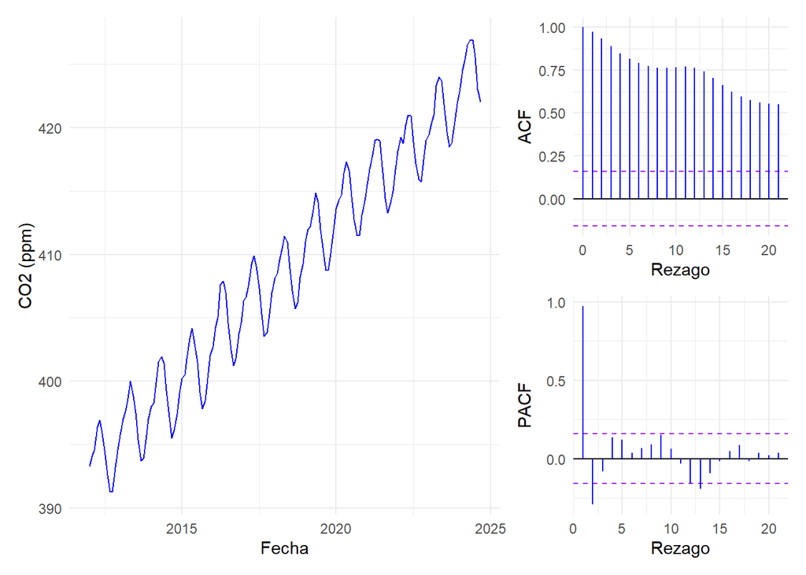

```r
graficar_serie(co2_train)
```

La serie de CO2 presenta una tendencia creciente y una marcada estacionalidad anual, con picos y valles que se repiten cada 12 meses. La ACF muestra un decaimiento lento y autocorrelaciones altas, lo que confirma una fuerte dependencia temporal. Por tanto, la serie no es estacionaria.

### 2.1.2 ¿Cuánto sube el $CO_2$ por año?

**Mostrar/ocultar código**

```r
# Incremento promedio anual
co2_train$incremento_anual <- co2_train$y - dplyr::lag(co2_train$y, 12)

incremento_promedio <- mean(
  co2_train$incremento_anual,
  na.rm = TRUE
)

# Incremento del último año
ultimo_anio <- tail(
  co2_train$incremento_anual[
    !is.na(co2_train$incremento_anual)
  ],
  1
)

cat(
  "Incremento anual promedio:", round(incremento_promedio, 2), "ppm\n",
  "Incremento del último año:", round(ultimo_anio, 2), "ppm\n"
)
```

```
Incremento anual promedio: 2.53 ppm
 Incremento del último año: 3.53 ppm
```

Usando únicamente los datos de entrenamiento, el $CO_2$ presenta un incremento anual promedio de 2,53 ppm. En el último año del entrenamiento, el aumento fue de 3,53 ppm, superior al promedio, lo que indica un crecimiento reciente más acelerado.

### 2.1.3 Máximo, mínimo y oscilación del ciclo anual

**Mostrar/ocultar código**

```r
meses <- c(
  "Enero", "Febrero", "Marzo", "Abril", "Mayo", "Junio",
  "Julio", "Agosto", "Septiembre", "Octubre", "Noviembre", "Diciembre"
)

# Patrón mensual
patron_mensual <- co2_train %>%
  mutate(anio = as.numeric(format(fecha, "%Y")),
         mes  = format(fecha, "%m")) %>%
  filter(anio <= 2023) %>%
  group_by(mes) %>%
  summarise(promedio = mean(y), .groups = "drop") %>%
  mutate(mes_nombre = meses[as.numeric(mes)])

mes_max <- patron_mensual %>% slice_max(promedio, n = 1)
mes_min <- patron_mensual %>% slice_min(promedio, n = 1)

oscilacion <- mes_max$promedio - mes_min$promedio

# Amplitud anual
amplitud_anual <- co2_train %>%
  mutate(anio = format(fecha, "%Y")) %>%
  group_by(anio) %>%
  filter(n() == 12) %>%
  summarise(maximo = max(y), minimo = min(y), nivel = mean(y),
            amplitud = maximo - minimo, .groups = "drop")

oscilacion_promedio <- mean(amplitud_anual$amplitud)
oscilacion_sd       <- sd(amplitud_anual$amplitud)

tabla_ciclo <- data.frame(
  Caracteristica = c(
    "Máximo promedio",
    "Mínimo promedio",
    "Oscilación del patrón (máx - mín)",
    "Oscilación anual media (máx - mín por año)",
    "Desviación estándar de la oscilación anual"
  ),
  Mes = c(
    mes_max$mes_nombre,
    mes_min$mes_nombre,
    paste(mes_max$mes_nombre, "-", mes_min$mes_nombre),
    "2012-2023",
    "2012-2023"
  ),
  CO2_ppm = c(
    mes_max$promedio,
    mes_min$promedio,
    oscilacion,
    oscilacion_promedio,
    oscilacion_sd
  )
)

tabla_ciclo$CO2_ppm <- round(tabla_ciclo$CO2_ppm, 2)

tabla_ciclo
```

| Caracteristica | Mes | CO2_ppm |
| --- | --- | --- |
| Máximo promedio | Mayo | 410.71 |
| Mínimo promedio | Septiembre | 404.74 |
| Oscilación del patrón (máx - mín) | Mayo - Septiembre | 5.97 |
| Oscilación anual media (máx - mín por año) | 2012-2023 | 5.99 |
| Desviación estándar de la oscilación anual | 2012-2023 | 0.43 |

El ciclo anual del CO2 alcanza su máximo en mayo (410,71 ppm) y su mínimo en septiembre (404,74 ppm), con una oscilación de 5,97 ppm en el patrón mensual de los 12 años completos (2012 a 2023). Medida año por año, la oscilación media es de 5,99 ppm, casi igual a la anterior, con una desviación estándar de 0,43 ppm, lo que indica que la amplitud del ciclo es muy estable de un año a otro.

### 2.1.4 Gráfico del ciclo anual

**Mostrar/ocultar código**

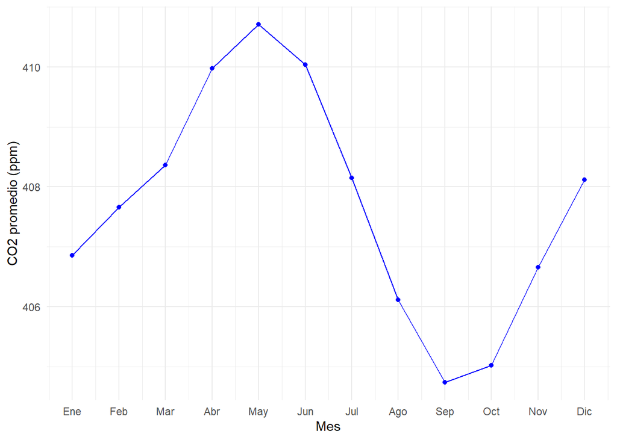

```r
meses <- c(
  "Ene", "Feb", "Mar", "Abr", "May", "Jun",
  "Jul", "Ago", "Sep", "Oct", "Nov", "Dic"
)

ggplot(patron_mensual,
       aes(x = as.numeric(mes), y = promedio)) +
  geom_line(color = "blue") +
  geom_point(color = "blue") +
  scale_x_continuous(
    breaks = 1:12,
    labels = meses
  ) +
  labs(
    x = "Mes",
    y = "CO2 promedio (ppm)"
  ) +
  theme_minimal()
```

El gráfico muestra el ciclo anual del $CO_2$, calculado con los datos de entrenamiento. Se observa un aumento desde enero hasta alcanzar un máximo en mayo, seguido de un descenso hasta septiembre, cuando se registra el mínimo. Posteriormente, el nivel vuelve a aumentar hacia diciembre, evidenciando un patrón estacional que se repite cada año.

### 2.1.5 ¿La amplitud cambia con el nivel?

**Mostrar/ocultar código**

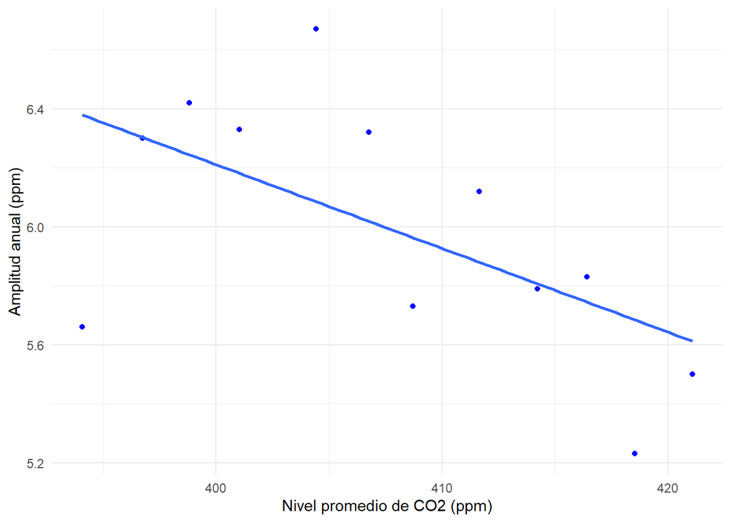

```r
ggplot(amplitud_anual,
       aes(x = nivel, y = amplitud)) +
  geom_point(color = "blue") +
  geom_smooth(method = "lm", se = FALSE) +
  labs(
    x = "Nivel promedio de CO2 (ppm)",
    y = "Amplitud anual (ppm)"
  ) +
  theme_minimal()
```

**Mostrar/ocultar código**

```r
correlacion <- cor(
  amplitud_anual$nivel,
  amplitud_anual$amplitud
)

cat(
  "Correlación entre el nivel promedio y la amplitud anual:",
  round(correlacion, 3),
  "\n"
)
```

```
Correlación entre el nivel promedio y la amplitud anual: -0.586
```

La amplitud anual del ciclo sí presenta un ligero cambio con el nivel de $CO_2$: tiende a disminuir a medida que aumenta la concentración ($r=-0,586$). Aunque los 12 puntos muestran cierta dispersión, la relación observada indica que la amplitud no aumenta con el nivel de la serie, sino que cambia ligeramente en sentido contrario al esperado si existiera un comportamiento multiplicativo marcado.

## 2.2 A2. ¿Hace falta transformar?

### 2.2.1 Perfil de Box-Cox

**Mostrar/ocultar código**

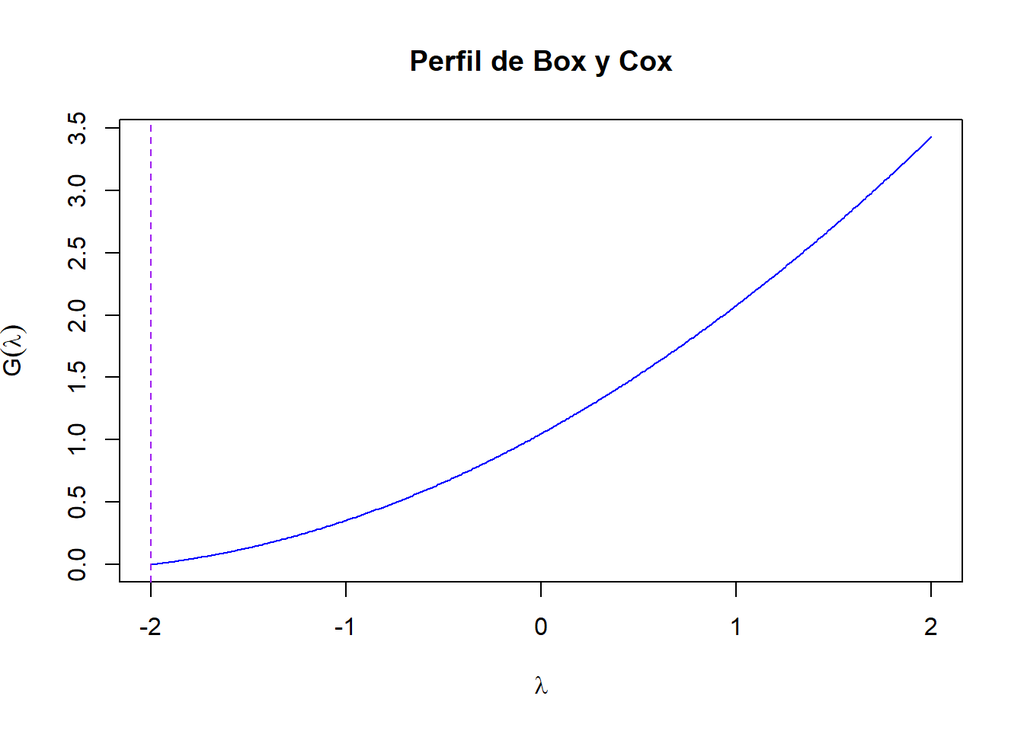

```r
res_A2 <- perfil_boxcox(co2_train$y)
```

### 2.2.2 Intervalo de compatibilidad del 95 %

**Mostrar/ocultar código**

```r
cat("Lambda óptimo:", res_A2$lambda_hat, "\n",
    "Intervalo de compatibilidad del 95%:", res_A2$ic[1], "a", res_A2$ic[2], "\n"
    )
```

```
Lambda óptimo: -2
 Intervalo de compatibilidad del 95%: -2 a 2
```

### 2.2.3 Variabilidad relativa de la serie

**Mostrar/ocultar código**

```r
variacion_relativa <- (
  max(co2_train$y) - min(co2_train$y)
) / min(co2_train$y) * 100

cat(
  "Variación relativa entre el mínimo y el máximo:",
  round(variacion_relativa, 2), "%\n"
)
```

```
Variación relativa entre el mínimo y el máximo: 9.11 %
```

### 2.2.4 Pruebas de hipótesis

#### 2.2.4.1 G(1)

$\textbf{Prueba de Hipótesis:}$

$$H_0:\lambda=1$$

$$H_1:\lambda\neq1$$

$\textbf{Estadístico de Prueba:}$

$$G(1)=m\ln\left(\frac{S(1)}{S(\hat\lambda)}\right)$$

$\textbf{Distribución bajo \(H_0\)}$

$$\chi^2_{gl=1}$$

$\textbf{Región de rechazo:}$

$$G(1)>3,841$$

**Mostrar/ocultar código**

```r
# Prueba de hipótesis para lambda = 1

G1 <- res_A2$G[which(res_A2$lambda == 1)]
valor_critico <- qchisq(0.95, df = 1)


cat("Estadístico de prueba G(1):", round(G1, 4), "\n",
    "Valor crítico:", round(valor_critico, 4), "\n",
    "Región de rechazo: G(1) >", round(valor_critico, 4), "\n")
```

```
Estadístico de prueba G(1): 2.0768
 Valor crítico: 3.8415
 Región de rechazo: G(1) > 3.8415
```

#### 2.2.4.2 G(0)

$\textbf{Prueba de Hipótesis:}$

$$H_0:\lambda=0$$

$$H_1:\lambda\neq0$$

$\textbf{Estadístico de Prueba:}$

$$G(0)=m\ln\left(\frac{S(0)}{S(\hat\lambda)}\right)$$

$\textbf{Distribución bajo \(H_0\)}$

$$\chi^2_{gl=1}$$

$\textbf{Región de rechazo:}$

$$G(1)>3,841$$

**Mostrar/ocultar código**

```r
# Prueba de hipótesis para lambda = 0

G2 <- res_A2$G[which(res_A2$lambda ==0)]
valor_critico2 <- qchisq(0.95, df = 1)

cat("Estadístico de prueba G(0):", round(G2, 4), "\n",
    "Valor crítico:", round(valor_critico2, 4), "\n",
    "Región de rechazo: G(0) >", round(valor_critico2, 4), "\n")
```

```
Estadístico de prueba G(0): 1.0495
 Valor crítico: 3.8415
 Región de rechazo: G(0) > 3.8415
```

El perfil de Box y Cox, calculado sobre el entrenamiento, es casi plano: G(λ) sube suavemente desde 0 en λ = -2 hasta cerca de 3,4 en λ = 2 y nunca alcanza el valor crítico $\chi^2_{1;0,95}$ = 3,8415. Por eso el intervalo del 95 % cubre toda la rejilla, de -2 a 2, y el $\hat{\lambda} = -2$ es solo el mínimo en el borde de la rejilla, no un valor que los datos prefieran de verdad. Para los dos valores que interesan, la región de rechazo al 5 % es $G(λ_0) > 3,8415$ y ninguno cae en ella: G(1) = 2,0768 (sin transformar) y G(0) = 1,0495 (logaritmo), de modo que no se rechaza λ = 1 ni λ = 0, y ambos son compatibles con los datos. El perfil casi no distingue entre transformaciones porque el nivel de la serie varía solo 9,11 % entre su mínimo y su máximo; en un rango tan angosto, $x^λ$, el logaritmo y la recta son prácticamente iguales, y el AR(4) de la doble diferencia tiene casi la misma suma de cuadrados con cualquiera de ellas. Como λ = 1 está dentro del intervalo y, según A1, la amplitud anual no crece con el nivel (r = -0,586), no hay señal de escala multiplicativa. Se decide no transformar (λ = 1), lo que además conserva la lectura en ppm y simplifica el pronóstico y sus intervalos.

## 2.3 A3. ¿Cuántas diferencias?

### 2.3.1 Primera diferencia ordinaria $\nabla Z_t$

**Mostrar/ocultar código**

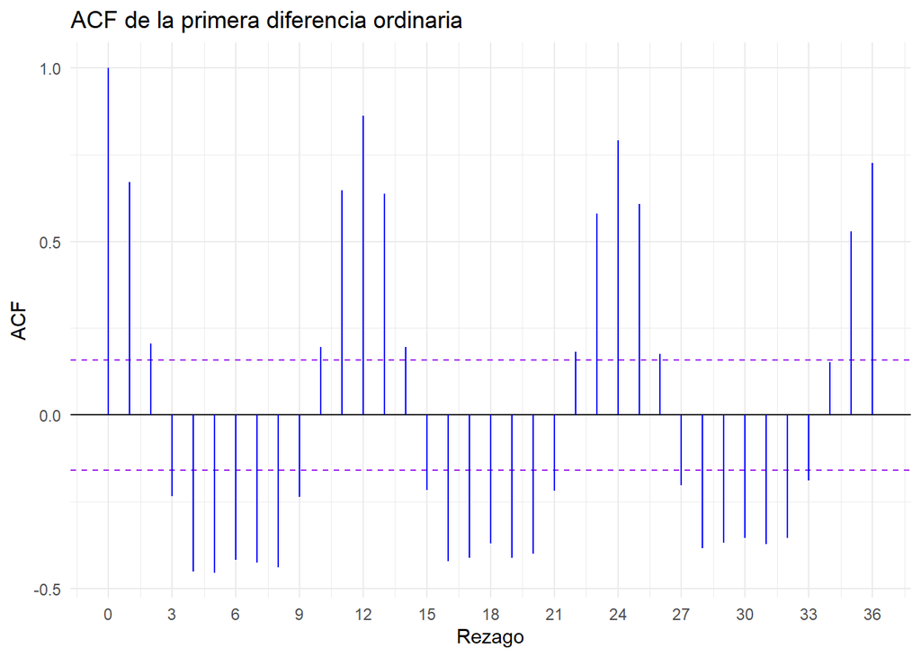

```r
d1 <- diff(co2_train$y)

graficar_acf(d1, titulo = "ACF de la primera diferencia ordinaria", lag.max = 36)
```

**Mostrar/ocultar código**

```r
cat("ACF en los rezagos 12, 24 y 36:",
    acf(d1, lag.max = 36, plot = FALSE)$acf[c(12, 24, 36) + 1], "\n")
```

```
ACF en los rezagos 12, 24 y 36: 0.8608572 0.790415 0.7260763
```

La primera diferencia ordinaria permitió eliminar la tendencia, pues la ACF ya no presenta un decaimiento lento. Sin embargo, el componente estacional persiste, como lo muestra la onda periódica marcada, con autocorrelaciones altas en los rezagos 12, 24 y 36, cuyos valores son 0,8609, 0,7904 y 0,7261, respectivamente, superan las bandas de confianza y no decaen rápidamente. Esto sugiere que la serie aún no es estacional estacionaria, por lo que se requiere aplicar una diferencia estacional.

### 2.3.2 Primera diferencia estacional $\nabla_{12} Z_t$

**Mostrar/ocultar código**

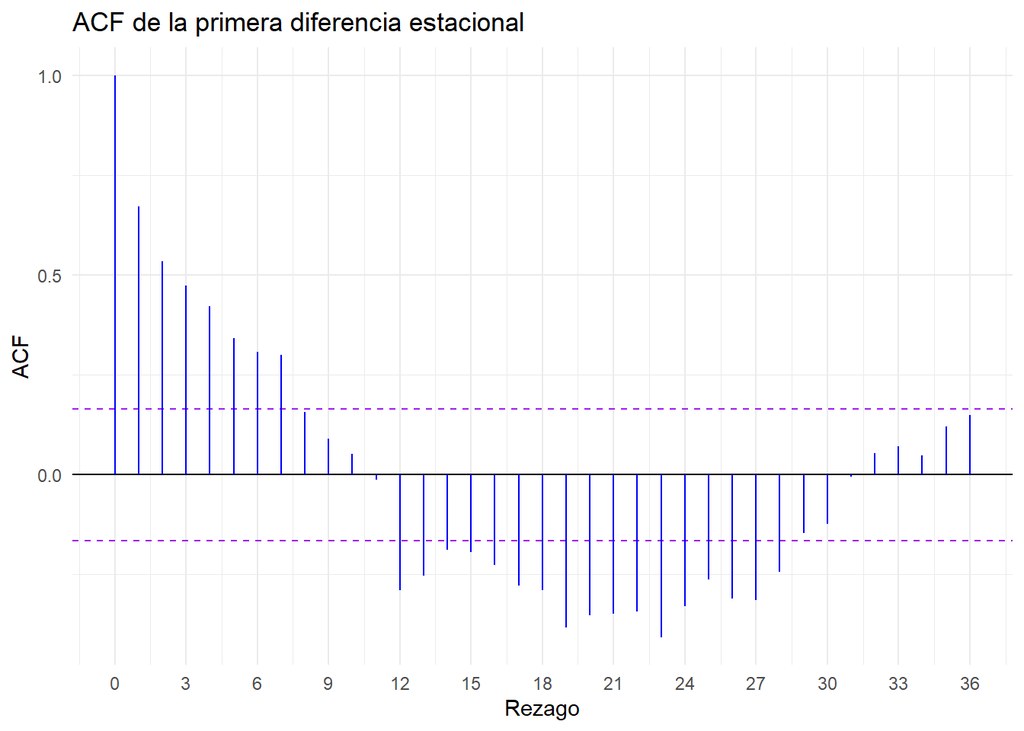

```r
# Primera diferencia estacional
d12 <- diff(co2_train$y, lag = 12)

graficar_acf(d12, titulo = "ACF de la primera diferencia estacional", lag.max = 36)
```

**Mostrar/ocultar código**

```r
cat("ACF en los rezagos 1 a 6:",
    acf(d12, lag.max = 6,  plot = FALSE)$acf[2:7], "\n")
```

```
ACF en los rezagos 1 a 6: 0.6709629 0.5342284 0.4738299 0.4216631 0.3408625 0.3074555
```

Al aplicar la diferencia estacional desaparece el patrón cíclico anual marcado. Sin embargo, persiste una correlación positiva en los primeros rezagos que disminuye gradualmente. Las autocorrelaciones en los rezagos 1 a 6 son 0,6710, 0,5342, 0,4738, 0,4217, 0,3409 y 0,3075, respectivamente. Este comportamiento, caracterizado por una disminución gradual de las autocorrelaciones, sugiere que la serie aún presenta no estacionariedad asociada a una tendencia. Por tanto, se requiere aplicar una diferencia ordinaria adicional, manteniendo la diferencia estacional.

### 2.3.3 Diferencia ordinaria y estacional $\nabla\nabla_{12}Z_t$

**Mostrar/ocultar código**

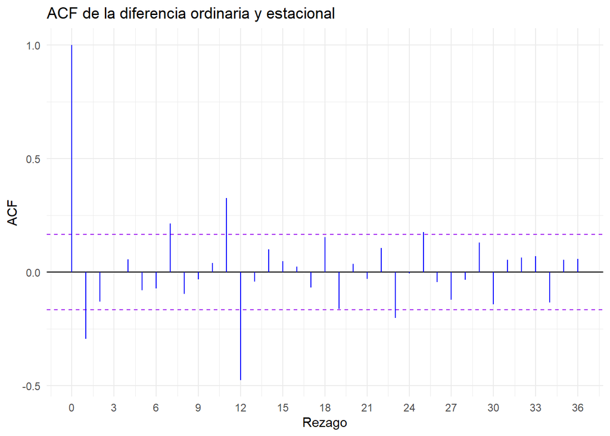

```r
# Diferencia regular y estacional
d1_d12 <- diff(d12)

graficar_acf(d1_d12, titulo = "ACF de la diferencia ordinaria y estacional", lag.max = 36)
```

Después de aplicar ambas diferencias, la ACF ya no presenta un decaimiento lento ni un patrón cíclico persistente. La mayoría de las autocorrelaciones oscilan alrededor de cero y se encuentran dentro de las bandas de confianza, lo que sugiere que la serie alcanzó la estacionariedad. Sin embargo, persisten algunos picos destacados en los rezagos 1, 11 y 12, que serán útiles para la identificación del modelo.

### 2.3.4 Justificación de d=1 y D=1

**Mostrar/ocultar código**

```r
# Diferencias adicionales
d2_d12 <- diff(d1_d12)              # d = 2, D = 1
d1_d12_2 <- diff(d1_d12, lag = 12)  # d = 1, D = 2

# Función para calcular n, varianza y rho(1)
resumen_diferencias <- function(serie, etapa) {

  data.frame(
    Etapa = etapa,
    n = length(serie),
    Varianza = var(serie),
    rho1 = acf(serie, lag.max = 1, plot = FALSE)$acf[2]
  )
}

# Tabla
tabla_diferencias <- dplyr::bind_rows(
  resumen_diferencias(co2_train$y, "Original"),
  resumen_diferencias(d1, "d = 1"),
  resumen_diferencias(d12, "D = 1"),
  resumen_diferencias(d1_d12, "d = 1, D = 1"),
  resumen_diferencias(d2_d12, "d = 2, D = 1"),
  resumen_diferencias(d1_d12_2, "d = 1, D = 2")
)

knitr::kable(
  tabla_diferencias,
  digits = 4,
  col.names = c(
    "Etapa", "n", "Varianza", expression(rho[1])
  ),
  caption = "Comparación de la varianza y la autocorrelación de primer orden"
)
```

Comparación de la varianza y la autocorrelación de primer orden

| Etapa | n | Varianza | rho[1] |
| --- | --- | --- | --- |
| Original | 153 | 88.7922 | 0.9743 |
| d = 1 | 152 | 1.8176 | 0.6697 |
| D = 1 | 141 | 0.4221 | 0.6710 |
| d = 1, D = 1 | 140 | 0.2725 | -0.2936 |
| d = 2, D = 1 | 139 | 0.7078 | -0.5613 |
| d = 1, D = 2 | 128 | 0.8348 | -0.3056 |

La serie original presenta una alta autocorrelación de primer orden ($\rho_1=0,9743$), asociada a su fuerte dependencia temporal. Después de aplicar las diferencias, la autocorrelación disminuye considerablemente y, con $d=1,D=1$, pasa a ser negativa ($\rho_1=-0,2936$). Al aplicar una diferencia regular adicional, la autocorrelación se hace aún más negativa ($\rho_1=-0,5613$) y la varianza aumenta de $0,2725$ a $0,7078$, lo que sugiere una posible sobrediferenciación. Por tanto, $d=1$ resulta suficiente.

De forma similar, aplicar una segunda diferencia estacional aumenta la varianza de $0,2725$ a $0,8348$, sin una reducción relevante de $\rho_1$. Esto indica que $D=1$ es suficiente y no se justifica utilizar $D=2$. En conjunto, los resultados apoyan la elección $d=1,\ D=1$.

### 2.3.5 Raíces unitarias estacionales con la prueba HEGY

$\textbf{Prueba de Hipótesis:}$

$\textbf{Prueba de Hipótesis:}$

$$H_0: \text{Hay raíz unitaria en la frecuencia cero}$$
$$H_1: \text{No hay raíz unitaria en la frecuencia cero}$$

$\textbf{Estadístico:}$

$$t_1=
\frac{\widehat{\pi}_1}
{\operatorname{EE}(\widehat{\pi}_1)}$$

No sigue una t de Student sino una distribución no estándar de tipo Dickey y Fuller, ajustada con constante, tendencia, dummies estacionales y 12 rezagos fijos (n = 153).

$\textbf{Región de rechazo:}$

$$\text{valor p} < 0,05$$

**Mostrar/ocultar código**

```r
co2_ts <- ts(co2_train$y, start = c(2012, 1), frequency = 12)

# Sin tendencia: constante + dummies estacionales
hegy_sin <- hegy.test(co2_ts, deterministic = c(1, 0, 1),
                      lag.method = "fixed", maxlag = 12)

# Con tendencia: constante + tendencia + dummies estacionales
hegy_con <- hegy.test(co2_ts, deterministic = c(1, 1, 1),
                      lag.method = "fixed", maxlag = 12)
```

**Mostrar/ocultar código**

```r
tabla_hegy <- data.frame(
  Frecuencia = names(hegy_sin$statistics),
  sin_est = hegy_sin$statistics, sin_p = hegy_sin$pvalues,
  con_est = hegy_con$statistics, con_p = hegy_con$pvalues
)

knitr::kable(
  tabla_hegy, digits = 4, row.names = FALSE,
  col.names = c("Frecuencia", "Estadístico (sin tend.)", "Valor p (sin tend.)",
                "Estadístico (con tend.)", "Valor p (con tend.)"),
  caption = "Prueba HEGY para el CO2 de entrenamiento (n = 153)"
)
```

Prueba HEGY para el CO2 de entrenamiento (n = 153)

| Frecuencia | Estadístico (sin tend.) | Valor p (sin tend.) | Estadístico (con tend.) | Valor p (con tend.) |
| --- | --- | --- | --- | --- |
| t_1 | 0.5552 | 0.9742 | -2.9695 | 0.0565 |
| t_2 | -1.4800 | 0.4205 | -1.5212 | 0.3934 |
| F_3:4 | 3.5835 | 0.1915 | 4.9848 | 0.0643 |
| F_5:6 | 4.9114 | 0.0728 | 5.6552 | 0.0376 |
| F_7:8 | 2.1498 | 0.4642 | 2.4391 | 0.3899 |
| F_9:10 | 4.6907 | 0.0861 | 5.0197 | 0.0625 |
| F_11:12 | 2.5254 | 0.3765 | 2.7363 | 0.3256 |
| F_2:12 | 4.2028 | 0.0741 | 4.7953 | 0.0256 |
| F_1:12 | 3.8694 | 0.1171 | 4.9163 | 0.0356 |

La prueba HEGY, con constante, dummies estacionales y 12 rezagos fijos, no permite rechazar la hipótesis de raíz unitaria regular ($t_1$), ya que los valores p son 0,9742 sin tendencia y 0,0565 con tendencia. Esto indica que existe evidencia de una raíz unitaria regular y apoya la elección de $d=1$.

En cuanto a las raíces estacionales, los resultados muestran diferencias entre las dos especificaciones. Sin tendencia, ninguna de las pruebas $F$ rechaza la hipótesis nula al 5 %. Con tendencia, se rechaza para $F_{5:6}$ $p=0,0376$ y para las pruebas conjuntas $F_{2:12}$ ($p=0,0256$) y $F_{1:12}$ ($p=0,0356$). En cambio, $F_{3:4}$, $F_{7:8}$, $F_{9:10}$ y $F_{11:12}$ no presentan evidencia suficiente para rechazarla.

Como la hipótesis nula de estas pruebas $F$ plantea la existencia de raíces unitarias estacionales, los resultados indican que la evidencia no es concluyente: depende de si se incluye o no la tendencia. Por tanto, no se puede afirmar que el ciclo anual del $CO_2$ esté completamente libre de raíces unitarias estacionales.

Si no existieran raíces unitarias estacionales, significaría que el patrón anual se mantiene relativamente estable a lo largo del tiempo, en lugar de cambiar de forma permanente de un año a otro.

A pesar de estos resultados, utilizar $D=1$ sigue siendo una aproximación razonable. Esto se debe a que la ACF de la primera diferencia ordinaria presenta autocorrelaciones altas en los rezagos 12, 24 y 36, lo que muestra una fuerte dependencia anual. Además, la prueba HEGY no rechaza la existencia de raíces estacionales en la mayoría de las frecuencias.

## 2.4 A4. Identificar el modelo

### 2.4.1 Gráfico de la serie diferenciada

**Mostrar/ocultar código**

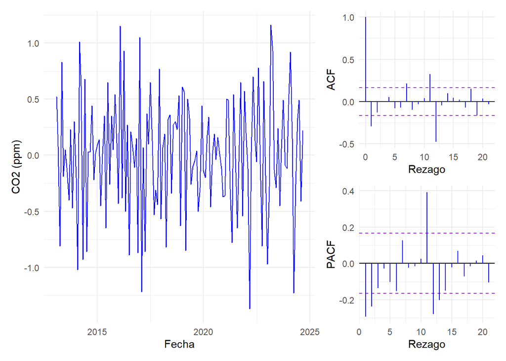

```r
d1_d12_df <- data.frame(
  fecha = co2_train$fecha[14:nrow(co2_train)],
  y = as.numeric(d1_d12)
)

graficar_serie(d1_d12_df)
```

La serie diferenciada no presenta tendencia, no muestra estacionalidad persistente, el patrón cíclico anual fue removido tras aplicar la diferencia estacional y sí es estacionaria, como lo confirma el rápido decaimiento de la ACF hacia cero dentro de las bandas de confianza.

**Mostrar/ocultar código**

```r
a <- acf(d1_d12,  lag.max = 24, plot = FALSE)$acf[-1]
p <- pacf(d1_d12, lag.max = 24, plot = FALSE)$acf

cat(
  "ACF en los rezagos 1, 2, 11, 12, 13 y 24:\n",
  round(a[c(1, 2, 11, 12, 13, 24)], 3), "\n\n",

  "PACF en los rezagos 1, 2, 11, 12, 13 y 24:\n",
  round(p[c(1, 2, 11, 12, 13, 24)], 3), "\n\n",

  "Banda de confianza al 95 %:\n",
  round(1.96 / sqrt(length(d1_d12)), 3), "\n"
)
```

```
ACF en los rezagos 1, 2, 11, 12, 13 y 24:
 -0.294 -0.13 0.326 -0.475 -0.043 -0.007

 PACF en los rezagos 1, 2, 11, 12, 13 y 24:
 -0.294 -0.237 0.392 -0.278 -0.202 -0.178

 Banda de confianza al 95 %:
 0.166
```

En la parte estacional, el rezago 12 presenta una autocorrelación de −0,475, que supera la banda, mientras que el rezago 24 (−0,007) queda dentro. Esto sugiere un componente MA estacional de orden $Q=1$. Además, el rezago 11 (0,326) también sobresale, lo cual puede explicarse por la combinación de los componentes MA regular y estacional.

En la PACF, los rezagos 1 y 2 (−0,294 y −0,237), así como los rezagos 11, 12 y 13 (0,392, −0,278 y −0,202), superan las bandas de confianza. Sin embargo, sus valores no muestran un corte claro, sino que disminuyen progresivamente. Este comportamiento también es compatible con componentes de promedio móvil.

Por tanto, la lectura conjunta de la ACF y la PACF sugiere utilizar el modelo:
$$SARIMA(0,1,1)(0,1,1)_{12}$$
### BIC

**Mostrar/ocultar código**

```r
ajustar <- function(p, q, P, Q) {
  arima(co2_train$y, order = c(p, 1, q),
        seasonal = list(order = c(P, 1, Q), period = 12))
}

cand <- data.frame(
  p = c(0, 0, 1, 1, 0),
  q = c(1, 2, 1, 0, 1),
  P = c(0, 0, 0, 0, 1),
  Q = c(1, 1, 1, 1, 1)
)

tabla_bic <- do.call(rbind, lapply(seq_len(nrow(cand)), function(i) {
  m <- with(cand[i, ], ajustar(p, q, P, Q))
  data.frame(
    Modelo = with(cand[i, ], sprintf("(%d,1,%d)(%d,1,%d)[12]", p, q, P, Q)),
    k = length(coef(m)),
    BIC = BIC(m)
  )
}))

tabla_bic <- tabla_bic[order(tabla_bic$BIC), ]
tabla_bic$dBIC <- tabla_bic$BIC - min(tabla_bic$BIC)
tabla_bic
```

|  | Modelo | k | BIC | dBIC |
| --- | --- | --- | --- | --- |
| 1 | (0,1,1)(0,1,1)[12] | 2 | 145.4775 | 0.000000 |
| 2 | (0,1,2)(0,1,1)[12] | 3 | 148.1385 | 2.661014 |
| 3 | (1,1,1)(0,1,1)[12] | 3 | 148.2782 | 2.800688 |
| 5 | (0,1,1)(1,1,1)[12] | 3 | 150.3236 | 4.846073 |
| 4 | (1,1,0)(0,1,1)[12] | 2 | 154.0393 | 8.561820 |

## 2.5 A5. Estimar, validar y buscar atípicos

### 2.5.1 Modelo estimado

$$(1-B)(1-B^{12})Z_t
=
(1-\theta_1B)(1-\Theta_1B^{12})a_t.$$

**Mostrar/ocultar código**

```r
m_A <- arima(co2_train$y, order = c(0, 1, 1),
             seasonal = list(order = c(0, 1, 1), period = 12))

est <- coef(m_A)
ee  <- sqrt(diag(m_A$var.coef))

tabla_modelo <- data.frame(
  Parametro  = c("theta1", "Theta1"),
  R          = est,
  Curso      = -est,                # theta1 = -ma1, Theta1 = -sma1
  EE         = ee,
  t          = est / ee,            # el signo del t cambia al convertir
  row.names  = NULL
)
tabla_modelo
```

| Parametro | R | Curso | EE | t |
| --- | --- | --- | --- | --- |
| theta1 | -0.4858379 | 0.4858379 | 0.08623412 | -5.633940 |
| Theta1 | -0.8160815 | 0.8160815 | 0.08679660 | -9.402229 |

Los resultados de la estimación muestran que ambos parámetros de promedio móvil son negativos en la salida de R: $\text{ma1}=-0,4858$ y $\text{sma1}=-0,8161$. Sin embargo, siguiendo la convención del curso, sus signos se invierten, por lo que se obtienen $\theta_1=0,4858$ y $\Theta_1=0,8161$.

Además, ambos parámetros presentan valores $t$ en valor absoluto superiores a 1,96 ($5,6339$ y $9,4022$, respectivamente), lo que indica que son estadísticamente significativos al 5 %. Por tanto, existe evidencia de que los componentes de promedio móvil regular y estacional contribuyen al modelo.

Los resultados respaldan la estructura del modelo $SARIMA(0,1,1)(0,1,1)_{12}$.

### 2.5.2 Ljung Box

$\textbf{Prueba ed Hipótesis:}$

$$H_0:\rho_1=\rho_2=\cdots=\rho_{24}=0$$

$$H_1:\text{Al menos una }\rho_k\neq 0$$
$\textbf{Estadístico de prueba:}$

$$Q= n(n+2)\sum_{k=1}^{24}
\frac{\hat{\rho}_k^2}{n-k}$$
$\textbf{Distribución bajo la hipótesis nula:}$

$\textbf{Región de Rechazo:}$

$$Q > \chi^2_{0.95,22}$$

**Mostrar/ocultar código**

```r
resultado_lb <- Box.test(
  residuals(m_A),
  lag = 24,
  type = "Ljung-Box",
  fitdf = 2
)

cat(
  "Prueba de Ljung-Box:\n",
  "Estadístico Q =", round(resultado_lb$statistic, 4), "\n",
  "Grados de libertad =", resultado_lb$parameter, "\n",
  "Valor p =", round(resultado_lb$p.value, 4), "\n"
)
```

```
Prueba de Ljung-Box:
 Estadístico Q = 19.3456
 Grados de libertad = 22
 Valor p = 0.6239
```

El resultado de la prueba de Ljung-Box presenta un valor $p=0,6239$, como es mayor al nivel de significancia del 5 %, no se rechaza la hipótesis nula de ausencia de autocorrelación hasta el rezago 24.

Por tanto, no hay evidencia suficiente de autocorrelación en los errores, lo que indica que estos se comportan aproximadamente como ruido blanco. El modelo supera satisfactoriamente esta prueba de validación.

**Mostrar/ocultar código**

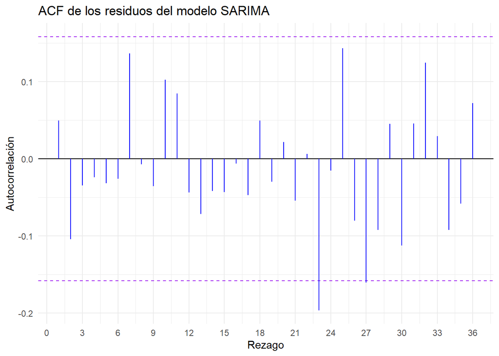

```r
residuos <- residuals(m_A)

acf_residuos <- acf(
  residuos,
  lag.max = 36,
  plot = FALSE
)

datos_acf <- data.frame(
  rezago = as.numeric(acf_residuos$lag)[-1],
  acf = as.numeric(acf_residuos$acf)[-1]
)

banda <- 1.96 / sqrt(length(residuos))

ggplot(datos_acf, aes(x = rezago, y = acf)) +
  geom_hline(yintercept = 0, color = "black") +
  geom_hline(
    yintercept = c(-banda, banda),
    color = "purple",
    linetype = "dashed"
  ) +
  geom_segment(
    aes(xend = rezago, y = 0, yend = acf),
    color = "blue"
  ) +
  scale_x_continuous(breaks = seq(0, 36, 3)) +
  labs(
    title = "ACF de los residuos del modelo SARIMA",
    x = "Rezago",
    y = "Autocorrelación"
  ) +
  theme_minimal()
```

La ACF confirma los resultados de Ljung-Box: 35 de los 36 rezagos están dentro de las bandas de confianza del 95 %. Aunque el rezago 23 las supera ligeramente, es un caso aislado. Por tanto, no se observa autocorrelación sistemática y los errores se comportan aproximadamente como ruido blanco.

### 2.5.3 Jarque Bera

$\textbf{Prueba de Hipótesis:}$

$$H_0: \text{Los errores siguen una distribución normal}$$
$$H_1: \text{Los errores no siguen una distribución normal}$$
$\textbf{Estadístico de prueba:}$

$$JB\sim\chi^2_2$$
$\textbf{Región de Rechazo:}$

$$JB > \chi^2_{0.95, 2}$$

**Mostrar/ocultar código**

```r
resultado_jb <- tseries::jarque.bera.test(residuals(m_A))
```

**Mostrar/ocultar código**

```r
cat(
  "Prueba de Jarque-Bera:\n",
  "Estadístico JB =", round(resultado_jb$statistic, 4), "\n",
  "Grados de libertad =", resultado_jb$parameter, "\n",
  "Valor p =", round(resultado_jb$p.value, 4), "\n"
)
```

```
Prueba de Jarque-Bera:
 Estadístico JB = 11.6168
 Grados de libertad = 2
 Valor p = 0.003
```

Como el valor $p=0,003$ es menor que el nivel de significancia de 0,05, se rechaza la hipótesis nula de normalidad. Por tanto, existe evidencia de que los errores del modelo no siguen una distribución normal.

**Mostrar/ocultar código**

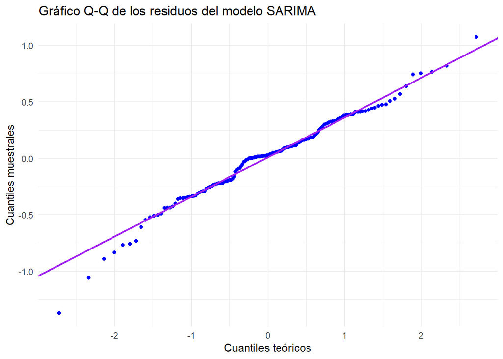

```r
ggplot(data.frame(residuos = as.numeric(residuals(m_A))),
       aes(sample = residuos)) +
  stat_qq(color = "blue") +
  stat_qq_line(color = "purple", linewidth = 1) +
  labs(
    title = "Gráfico Q-Q de los residuos del modelo SARIMA",
    x = "Cuantiles teóricos",
    y = "Cuantiles muestrales"
  ) +
  theme_minimal()
```

El gráfico Q-Q muestra un buen ajuste en la parte central, pero desviaciones importantes en la cola izquierda y un ligero alejamiento en la cola derecha. Esto evidencia falta de normalidad, principalmente por la presencia de valores extremos negativos, en relación con el resultado significativo de Jarque-Bera ($p=0,003$).

### 2.5.4 Valores Atípicos

**Mostrar/ocultar código**

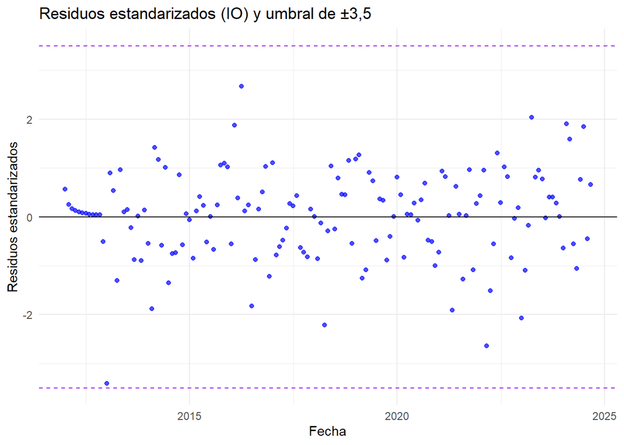

```r
det_A <- detectar_atipicos(m_A)

e_est <- as.numeric(residuals(m_A)) / det_A$sigma

datos_est <- data.frame(
  fecha = co2_train$fecha,
  e_est = e_est
)

ggplot(datos_est, aes(x = fecha, y = e_est)) +
  geom_point(color = "blue", alpha = 0.7) +
  geom_hline(yintercept = c(-3.5, 3.5), linetype = "dashed", color = "purple") +
  geom_hline(yintercept = 0) +
  labs(
    title = "Residuos estandarizados (IO) y umbral de ±3,5",
    x = "Fecha",
    y = "Residuos estandarizados"
  ) +
  theme_minimal()
```

El gráfico muestra que todos los residuos estandarizados se encuentran dentro de los límites de $\pm 3,5$. Por tanto, no se detectan valores atípicos innovadores (IO) significativos. Se observa una observación negativa cercana al límite inferior alrededor de 2013, pero no supera el umbral establecido.

**Mostrar/ocultar código**

```r
det_A <- detectar_atipicos(m_A)

cat("Sigma robusta:", round(det_A$sigma, 4), "\n")
```

```
Sigma robusta: 0.4021
```

**Mostrar/ocultar código**

```r
cat("Máximo valor absoluto:", round(det_A$max_abs, 4), "\n")
```

```
Máximo valor absoluto: 3.3149
```

**Mostrar/ocultar código**

```r
print(det_A$detectados)
```

```
[1] T      tipo   lambda sig
<0 rows> (or 0-length row.names)
```

**Mostrar/ocultar código**

```r
det_A$todo[which.max(abs(det_A$todo$lambda)), ]
```

|  | T | tipo | lambda | sig |
| --- | --- | --- | --- | --- |
| 156 | 52 | TC | 3.314886 | FALSE |

**Mostrar/ocultar código**

```r
T0 <- 50
det_A$todo[det_A$todo$T == T0 & det_A$todo$tipo == "IO", "lambda"]
```

```
[1] 1.872796
```

**Mostrar/ocultar código**

```r
residuals(m_A)[T0] / det_A$sigma
```

```
[1] 1.872796
```

La búsqueda de atípicos utiliza $\delta=0,7$ y una desviación estándar robusta de $0,4021$. El mayor valor absoluto encontrado fue $3,315$, correspondiente a un cambio transitorio (TC) en $T=52$. Como no supera el umbral de $3,5$, no se identifican observaciones atípicas.

### 2.5.5 Sobreajuste

**Mostrar/ocultar código**

```r
sobreajuste <- rbind(
  sobreajustar(0, 2, 0, 1, "ma2"),
  sobreajustar(1, 1, 0, 1, "ar1"),
  sobreajustar(0, 1, 1, 1, "sar1")
)

sobreajuste
```

|  | Modelo | Extra | Estimacion | EE | t | Significativo |
| --- | --- | --- | --- | --- | --- | --- |
| ma2 | (0,1,2)(0,1,1)[12] | ma2 | -0.12221747 | 0.07991998 | -1.5292479 | FALSE |
| ar1 | (1,1,1)(0,1,1)[12] | ar1 | 0.22522903 | 0.14856791 | 1.5160005 | FALSE |
| sar1 | (0,1,1)(1,1,1)[12] | sar1 | -0.03741344 | 0.12057828 | -0.3102834 | FALSE |

En los tres modelos de sobreajuste, los parámetros adicionales presentan valores de $|t|$ inferiores a 1,96, por lo que ninguno es estadísticamente significativo al 5 %. Esto indica que agregar un segundo componente MA regular, un componente AR regular o un componente AR estacional no mejora suficientemente el modelo original. Por tanto, se mantiene el modelo $SARIMA(0,1,1)(0,1,1)_{12}$, por ser más parsimonioso.

### 2.5.6 Intervalo de confianza $\hat{\Theta}$

**Mostrar/ocultar código**

```r
Theta <- -coef(m_A)["sma1"]
ee_Theta <- sqrt(diag(m_A$var.coef))["sma1"]

IC <- Theta + c(-1, 1) * 1.96 * ee_Theta

cat(
  "Intervalo de confianza del 95 % para Theta:\n",
  "Límite inferior =", round(IC[1], 4), "\n",
  "Límite superior =", round(IC[2], 4), "\n"
)
```

```
Intervalo de confianza del 95 % para Theta:
 Límite inferior = 0.646
 Límite superior = 0.9862
```

El intervalo del 95 % para $\Theta_1$ es [0,646; 0,986]. No contiene el 1, aunque su extremo superior queda muy cerca de él. Un $\Theta_1$ cercano a 1 indica que el patrón estacional es casi determinista: se repite de un año a otro con muy poca evolución, y la diferencia estacional con D = 1 lo elimina a costa de cierta sobrediferenciación. Esto concuerda con la amplitud estable del ciclo en A1 y con HEGY, que no permitió afirmar con claridad que el ciclo anual tuviera raíces unitarias estacionales. Si $\Theta_1$ fuera exactamente 1, el patrón sería fijo y el pronóstico de largo plazo lo repetiría sin cambios.

## 2.6 A6. ¿Le gana el SARIMA a las referencias?

### 2.6.1 Medidas de error

**Mostrar/ocultar código**

```r
y_train <- co2_train$y
y_test  <- co2_test$y

h <- nrow(co2_test)

# SARIMA
pron_sarima <- predict(m_A, n.ahead = h)$pred

# Ingenuo estacional
pron_snaive <- tail(y_train, 12)[(seq_len(h) - 1) %% 12 + 1]

# Holt-Winters aditivo
y_train_ts <- ts(y_train, start = c(2012, 1), frequency = 12)
modelo_hw  <- HoltWinters(y_train_ts, seasonal = "additive")
pron_hw    <- predict(modelo_hw, n.ahead = h)
```

**Mostrar/ocultar código**

```r
# Escala del ingenuo estacional
escala_mase <- mean(
  abs(y_train[(12 + 1):length(y_train)] - y_train[1:(length(y_train) - 12)])
)
```

**Mostrar/ocultar código**

```r
resultados <- rbind(
  SARIMA = metricas(y_test, pron_sarima, escala_mase),
  `Ingenuo estacional` = metricas(y_test, pron_snaive, escala_mase),
  `Holt-Winters` = metricas(y_test, pron_hw, escala_mase)
)

round(resultados, 3)
```

```
                    RMSE  MAPE  MASE
SARIMA             0.225 0.049 0.082
Ingenuo estacional 3.066 0.708 1.196
Holt-Winters       0.282 0.056 0.095
```

En el tramo de validación, el modelo SARIMA presenta el mejor desempeño en las tres medidas: RMSE = 0,225 ppm, MAPE = 0,049 % y MASE = 0,082, frente a 0,282, 0,056 % y 0,095 de Holt-Winters aditivo, y 3,066, 0,708 % y 1,196 del ingenuo estacional. El MASE expresa el error absoluto medio en unidades del error del ingenuo estacional en el entrenamiento: un valor de 0,082 indica que el SARIMA presenta un error equivalente al 8,2 % del error de referencia, es decir, unas 12 veces menor. El ingenuo pierde tanto porque repite el valor de hace un año y no incorpora el crecimiento de la serie, de modo que su error se acerca al incremento anual (aprox 3 ppm). Holt-Winters queda cerca del SARIMA, y su diferencia en RMSE es de solo 0,057 ppm.

### 2.6.2 Intervalo de confianza

**Mostrar/ocultar código**

```r
h <- nrow(co2_test)

pr <- predict(m_A, n.ahead = h)

pron_sarima_ic <- data.frame(
  fecha = co2_test$fecha,
  observado = co2_test$y,
  pron = as.numeric(pr$pred),
  se = as.numeric(pr$se),
  li = as.numeric(pr$pred) - qnorm(0.975) * as.numeric(pr$se),
  ls = as.numeric(pr$pred) + qnorm(0.975) * as.numeric(pr$se)
)

pron_sarima_ic$en_intervalo <- with(
  pron_sarima_ic,
  observado >= li & observado <= ls
)

pron_sarima_ic
```

| fecha | observado | pron | se | li | ls | en_intervalo |
| --- | --- | --- | --- | --- | --- | --- |
| 2024-10-01 | 422.38 | 422.1510 | 0.3683407 | 421.4291 | 422.8729 | TRUE |
| 2024-11-01 | 423.85 | 423.7647 | 0.4141766 | 422.9529 | 424.5765 | TRUE |
| 2024-12-01 | 425.40 | 425.2078 | 0.4554225 | 424.3152 | 426.1004 | TRUE |
| 2025-01-01 | 426.65 | 426.3578 | 0.4932037 | 425.3911 | 427.3244 | TRUE |
| 2025-02-01 | 427.09 | 427.3827 | 0.5282863 | 426.3472 | 428.4181 | TRUE |
| 2025-03-01 | 428.15 | 427.9947 | 0.5611801 | 426.8948 | 429.0946 | TRUE |
| 2025-04-01 | 429.64 | 429.5602 | 0.5922497 | 428.3994 | 430.7210 | TRUE |
| 2025-05-01 | 430.51 | 430.2087 | 0.6217687 | 428.9901 | 431.4274 | TRUE |
| 2025-06-01 | 429.61 | 429.8003 | 0.6499483 | 428.5264 | 431.0742 | TRUE |
| 2025-07-01 | 427.87 | 427.9579 | 0.6769560 | 426.6311 | 429.2848 | TRUE |

[output cut: 2 more lines]

De los 12 valores observados en el tramo de validación, los 12 se encuentran dentro del intervalo de predicción del 95 % del SARIMA, obteniéndose una cobertura de 100 %. Esto indica una buena capacidad del modelo para representar la incertidumbre asociada a los pronósticos, ya que todos los valores observados fueron contenidos por los intervalos.

## 2.7 A7. El pronóstico del tablero

### 2.7.1 Justificación método elegido

Para el tablero se eligió el $SARIMA(0,1,1)(0,1,1)_{12}$, reajustado con los 165 meses y con los mismos órdenes identificados en el entrenamiento. En A5 el modelo cumple los supuestos: el Ljung y Box con K = 24 no detecta autocorrelación residual (valor p = 0.6239), la búsqueda de atípicos no declara ninguno (máximo $|λ_j(T)|$ = 3,315 < 3,5) y los parámetros adicionales no son significativos, además de tener el menor BIC (145,48) con solo dos parámetros. En A6 obtuvo el menor error en el tramo de validación (RMSE = 0,225 ppm, MAPE = 0,049 % y MASE = 0,082), y 12 de los 12 valores observados cayeron dentro de su intervalo del 95 %. Holt-Winters quedó cerca (RMSE = 0,282 ppm), por lo que la ventaja del SARIMA es real pero pequeña, y el ingenuo estacional quedó muy atrás (RMSE = 3,066 ppm). Se prefiere el SARIMA porque, además de pronosticar mejor, entrega intervalos con base en un modelo validado.

### 2.7.2 Pronóstico mayo 2026

**Mostrar/ocultar código**

```r
# Serie completa
y_full <- ts(c(co2_train$y, co2_test$y), start = c(2012, 1), frequency = 12)

m_final <- arima(y_full, order = c(0, 1, 1),
                 seasonal = list(order = c(0, 1, 1), period = 12))

h  <- 12
pr <- predict(m_final, n.ahead = h)

pron_2026 <- data.frame(
  fecha = seq(as.Date("2025-10-01"), by = "month", length.out = h),
  pron  = as.numeric(pr$pred),
  se    = as.numeric(pr$se)
)
pron_2026$li <- pron_2026$pron - qnorm(0.975) * pron_2026$se
pron_2026$ls <- pron_2026$pron + qnorm(0.975) * pron_2026$se

pron_2026
```

| fecha | pron | se | li | ls |
| --- | --- | --- | --- | --- |
| 2025-10-01 | 424.6310 | 0.3530745 | 423.9390 | 425.3230 |
| 2025-11-01 | 426.2424 | 0.3953029 | 425.4676 | 427.0171 |
| 2025-12-01 | 427.7022 | 0.4334364 | 426.8526 | 428.5517 |
| 2026-01-01 | 428.9000 | 0.4683844 | 427.9819 | 429.8180 |
| 2026-02-01 | 429.7697 | 0.5008964 | 428.7880 | 430.7515 |
| 2026-03-01 | 430.4890 | 0.5314231 | 429.4474 | 431.5306 |
| 2026-04-01 | 432.0506 | 0.5602890 | 430.9525 | 433.1488 |
| 2026-05-01 | 432.7601 | 0.5877390 | 431.6081 | 433.9120 |
| 2026-06-01 | 432.1754 | 0.6139628 | 430.9721 | 433.3788 |
| 2026-07-01 | 430.3340 | 0.6391116 | 429.0814 | 431.5867 |

[output cut: 2 more lines]

**Mostrar/ocultar código**

```r
mayo <- pron_2026 %>% filter(fecha == as.Date("2026-05-01"))

primero_430 <- pron_2026 %>% filter(pron > 430) %>% slice(1)

cat(
  "Pronóstico de mayo de 2026:", round(mayo$pron, 3), "ppm\n",
  "IC 95%: [", round(mayo$li, 3), ",", round(mayo$ls, 3), "] ppm\n"
)
```

```
Pronóstico de mayo de 2026: 432.76 ppm
 IC 95%: [ 431.608 , 433.912 ] ppm
```

**Mostrar/ocultar código**

```r
# Primer mes con pronóstico > 430 ppm
if (nrow(primero_430) > 0) {
  cat(
    "Primer mes con pronóstico > 430 ppm:\n",
    "Fecha =", format(primero_430$fecha, "%Y-%m"), "\n",
    "Pronóstico =", round(primero_430$pron, 3), "ppm\n\n"
  )
} else {
  cat("Ningún mes del horizonte supera 430 ppm\n\n")
}
```

```
Primer mes con pronóstico > 430 ppm:
 Fecha = 2026-03
 Pronóstico = 430.489 ppm
```

**Mostrar/ocultar código**

```r
# Primer mes cuyo límite inferior supera 430 ppm
pos_li <- which(pron_2026$li > 430)[1]

if (!is.na(pos_li)) {
  cat(
    "Primer mes cuyo límite inferior del IC 95% supera 430 ppm:\n",
    "Fecha =", format(pron_2026$fecha[pos_li], "%Y-%m"), "\n",
    "Límite inferior =", round(pron_2026$li[pos_li], 3), "ppm\n\n"
  )
} else {
  cat(
    "Ningún límite inferior del IC 95% supera 430 ppm en el horizonte\n\n"
  )
}
```

```
Primer mes cuyo límite inferior del IC 95% supera 430 ppm:
 Fecha = 2026-04
 Límite inferior = 430.952 ppm
```

**Mostrar/ocultar código**

```r
# Ancho del intervalo en el primer y duodécimo mes
ancho_intervalo <- 2 * qnorm(0.975) * pron_2026$se[c(1, 12)]

cat(
  "Ancho del intervalo de predicción:\n",
  "Primer mes =", round(ancho_intervalo[1], 3), "ppm\n",
  "Mes 12 =", round(ancho_intervalo[2], 3), "ppm\n\n"
)
```

```
Ancho del intervalo de predicción:
 Primer mes = 1.384 ppm
 Mes 12 = 2.692 ppm
```

**Mostrar/ocultar código**

```r
# Aumento relativo del error estándar
cociente_se <- pron_2026$se[12] / pron_2026$se[1]

cat(
  "Cociente del error estándar (mes 12 / mes 1):\n",
  round(cociente_se, 3), "\n"
)
```

```
Cociente del error estándar (mes 12 / mes 1):
 1.945
```

El pronóstico de mayo de 2026, que corresponde al máximo estacional, es de 432,760 ppm, con un intervalo del 95 % de [431,608; 433,912] ppm. El primer mes en que el pronóstico supera los 430 ppm es marzo de 2026, con 430,489 ppm.

El intervalo de septiembre de 2026 es más ancho que el de octubre de 2025 porque, a medida que aumenta el horizonte de pronóstico, crece la incertidumbre y el modelo acumula el efecto de errores futuros. Por eso, el intervalo pasa de un ancho de 1,384 ppm a 2,692 ppm.

Un supuesto que podría fallar es que el comportamiento de la serie se mantenga estable. Por ejemplo, si el próximo año ocurre un cambio inesperado en el crecimiento del $CO_2$, el modelo podría no anticiparlo.

El equipo apuesta a que el observatorio registró por primera vez más de 430 ppm en marzo de 2026, aunque con poca firmeza: el pronóstico supera 430 por solo 0,49 ppm, y el intervalo de ese mes, [429,447; 431,531], incluye valores por debajo de 430. Marzo y abril son los dos meses plausibles, y abril es donde ya el límite inferior supera 430.

### 2.7.3 Tablero

**Mostrar/ocultar código**

```r
apellidos <- "pulgarin-valencia"

# pron_2026 es la tabla de 12 filas de A7 (ajustada con los 165 meses)
stopifnot(nrow(pron_2026) == 12)
stopifnot(format(pron_2026$fecha[1], "%Y-%m") == "2025-10",
          format(pron_2026$fecha[12], "%Y-%m") == "2026-09")

salida <- data.frame(
  pareja     = apellidos,
  fecha      = format(pron_2026$fecha, "%Y-%m"),
  pronostico = sprintf("%.3f", pron_2026$pron)
)

archivo <- paste0("reto-co2_", apellidos, ".csv")
write.csv(salida, archivo, row.names = FALSE, quote = FALSE)

# Verificación: debe verse con 12 filas y 3 columnas
read.csv(archivo)
```

| pareja | fecha | pronostico |
| --- | --- | --- |
| pulgarin-valencia | 2025-10 | 424.631 |
| pulgarin-valencia | 2025-11 | 426.242 |
| pulgarin-valencia | 2025-12 | 427.702 |
| pulgarin-valencia | 2026-01 | 428.900 |
| pulgarin-valencia | 2026-02 | 429.770 |
| pulgarin-valencia | 2026-03 | 430.489 |
| pulgarin-valencia | 2026-04 | 432.051 |
| pulgarin-valencia | 2026-05 | 432.760 |
| pulgarin-valencia | 2026-06 | 432.175 |
| pulgarin-valencia | 2026-07 | 430.334 |

[output cut: 2 more lines]

**Mostrar/ocultar código**

```r
cat(readLines(archivo), sep = "\n")
```

```
pareja,fecha,pronostico
pulgarin-valencia,2025-10,424.631
pulgarin-valencia,2025-11,426.242
pulgarin-valencia,2025-12,427.702
pulgarin-valencia,2026-01,428.900
pulgarin-valencia,2026-02,429.770
pulgarin-valencia,2026-03,430.489
pulgarin-valencia,2026-04,432.051
pulgarin-valencia,2026-05,432.760
pulgarin-valencia,2026-06,432.175
pulgarin-valencia,2026-07,430.334
pulgarin-valencia,2026-08,428.217
pulgarin-valencia,2026-09,426.925
```

# 3 CASO 2 Viajeros Reino unido - Australia

**Mostrar/ocultar código**

```r
# paquetes

library(forecast)
library(ggplot2)
library(patchwork)
library(tseries)
```

**Mostrar/ocultar código**

```r
library(readr)
library(TSA)
```

**Mostrar/ocultar código**

```r
library(urca)
library(tsoutliers)
```

**Mostrar/ocultar código**

```r
library(tibble)
library(dplyr)
library(stats)
```

**Mostrar/ocultar código**

```r
 Serie_B_DT <- read_csv("datos/turistas-reino-unido-australia-trimestral.csv")
```

**Mostrar/ocultar código**

```r
# objeto ts


SerieB_or <- Serie_B_DT |>
  mutate(
    anio      = as.numeric(sub("-T.*$", "", trimestre)),  # año
    trim      = as.numeric(sub("^.*-T", "", trimestre))   # trimestre
  ) |>
  arrange(anio, trim)

# 3. Punto de inicio de la serie
anio_inicio <- min(SerieB_or$anio)
trim_inicio <- SerieB_or$trim[SerieB_or$anio == anio_inicio][1]

# 4. Serie ts trimestral
serie_ts_B <- ts(
  SerieB_or$llegadas_miles,
  start = c(anio_inicio, trim_inicio),
  frequency = 4
)


Serie_B <- leer_serie(serie_ts_B, "Aerolineas UK-AUST",
                      "Numero de turistas registrados")

remove(anio_inicio, trim_inicio, Serie_B_DT, SerieB_or)
```

## 3.1 Grafico y ACF/PACF

**Mostrar/ocultar código**

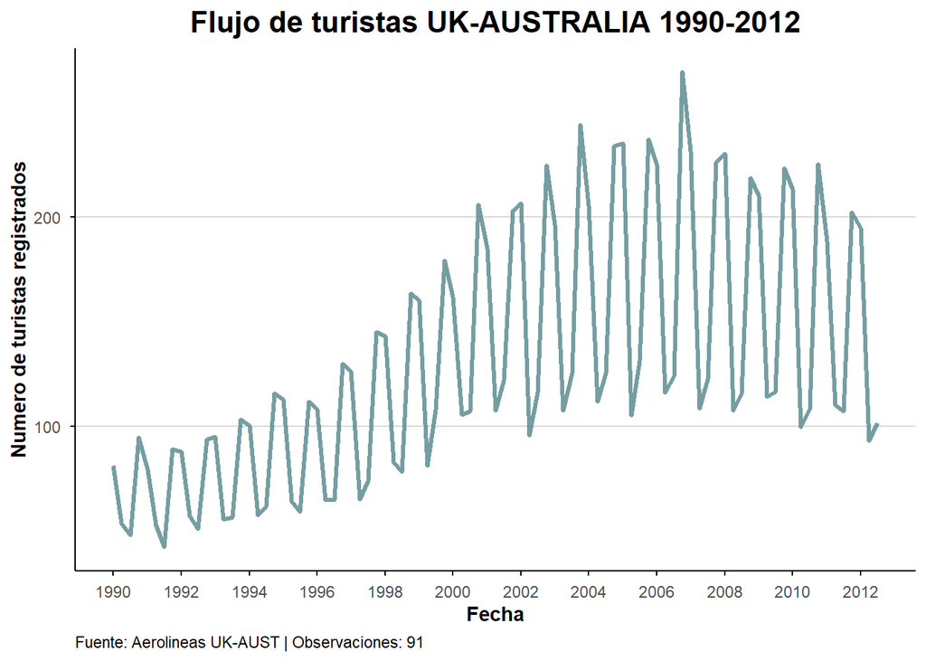

```r
graficar_serie(Serie_B, "Flujo de turistas UK-AUSTRALIA 1990-2012", color = "#53868B", mostrar_puntos = FALSE)
```

**Mostrar/ocultar código**

```r
Corre_OG <- correlograma(Serie_B, m = 24)
```

**Mostrar/ocultar código**

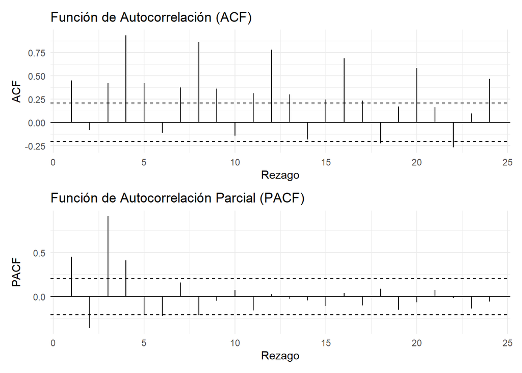

```r
Corre_OG$panel
```

## 3.2 B1 Tranformacion

**Mostrar/ocultar código**

```r
lambda <- BoxCox.lambda(serie_ts_B, method = "guerrero")
lambda
```

```
[1] -0.2262569
```

### 3.2.1 Separacion de datos

**Mostrar/ocultar código**

```r
h     <- 8                                            # Para validacion
train <- window(serie_ts_B, end   = c(2010, 3))       # entrenamiento
test  <- window(serie_ts_B, start = c(2010, 4))       # validación: 2010-T4 a 2012-T3
```

### 3.2.2 Analisis de oscilacion

**Mostrar/ocultar código**

```r
# Oscilación dentro de cada año: rango (máx - mín) y media anual
df_B <- data.frame(valor = as.numeric(serie_ts_B),
                   anio  = floor(time(serie_ts_B)),
                   trim  = cycle(serie_ts_B))

osc_anual <- do.call(rbind, lapply(split(df_B$valor, df_B$anio), function(z)
  data.frame(media = mean(z), rango = max(z) - min(z))))

osc_anual$cociente <- osc_anual$rango / osc_anual$media

round(osc_anual[c("1990", "1991", "1992" , "2004", "2005", "2006"), ], 2)
```

|  | media | rango | cociente |
| --- | --- | --- | --- |
| 1990 | 69.44 | 46.79 | 0.67 |
| 1991 | 65.93 | 46.67 | 0.71 |
| 1992 | 72.48 | 42.68 | 0.59 |
| 2004 | 169.06 | 121.84 | 0.72 |
| 2005 | 177.20 | 131.68 | 0.74 |
| 2006 | 183.56 | 153.08 | 0.83 |

En 1990 la oscilación dentro del año va de unos 48 a 95 mil visitantes, con rango cercano a 46.79 y media de 69.44 . En 2005 el rango de 131.68 y en 2006 de 153.08 indicando que el rango a aumentando significativamente con los añós y por ende no existe una varianza constante.

La amplitud crece con el nivel, mientras el cociente rango/media varia en un rango un poco amplio con una media de alrededor de 0.71 . Por lo que puede existir una escala multiplicativa favoreciendo a una transformacicion log

### 3.2.3 Prueba de lambda

**Mostrar/ocultar código**

```r
# Perfil de Box-Cox según la definición del enunciado
n     <- length(serie_ts_B)     #
s     <- 4
nstar <- n - s - 5              # 82

S_lambda <- function(lam, x, s = 4) {
  x <- as.numeric(x)
  g <- exp(mean(log(x)))                              # mediageométrica

  z <- if (abs(lam) < 1e-8) g * log(x) else (x^lam - 1) / (lam * g^(lam - 1))
  w <- diff(diff(z, lag = s))                              # ∇∇_s Z^(λ)
  W <- embed(w, 5)                                         # AR(4) con constante
  sum(residuals(lm(W[, 1] ~ W[, -1]))^2)
}

lam_hat  <- optimize(S_lambda, interval = c(-2, 2), x = serie_ts_B)$minimum

S_hat    <- S_lambda(lam_hat, serie_ts_B)

G_lambda <- function(lam) nstar * log(S_lambda(lam, serie_ts_B) / S_hat)

tabla_G <- data.frame(lambda = c(1, 0.5, 0, lam_hat))
tabla_G$G       <- sapply(tabla_G$lambda, G_lambda)
tabla_G$p_valor <- pchisq(tabla_G$G, df = 1, lower.tail = FALSE)
tabla_G
```

| lambda | G | p_valor |
| --- | --- | --- |
| 1.00000000 | 39.0207297 | 4.193292e-10 |
| 0.50000000 | 9.2333288 | 2.376492e-03 |
| 0.00000000 | 0.3267158 | 5.675993e-01 |
| 0.07668077 | 0.0000000 | 1.000000e+00 |

**Mostrar/ocultar código**

```r
qchisq(0.95, df = 1)
```

```
[1] 3.841459
```

**Mostrar/ocultar código**

```r
# Intervalo de λ compatible con los datos: G(λ) <= 3,841
grid_lam <- seq(-1, 2, by = 0.01)
G_grid   <- sapply(grid_lam, G_lambda)
range(grid_lam[G_grid <= qchisq(0.95, 1)])
```

```
[1] -0.18  0.34
```

**Mostrar/ocultar código**

```r
lambda
```

```
[1] -0.2262569
```

Prueba de H0: λ = 1:

$$H_0: \lambda = 1 \ ; H_1 : \lambda \neq 1$$

El estadistico para $G(1) = n* ln[S(1)/S(λ)]$ con $n^*=82$ bajo la hipotesis nula se distribuye comp $\chi^2_1$

Su region de rechazo es $G(1) > 3.841$

Valores observados de la prueba:

$$G(1) = [ 39.02 ] \ ; \ valor \ p = [ 4.1932e-10 ].$$

Decisión: se rechaza $H_0$ y se hace una tranformacion logaritmica a los datos para estabilizar la varianza

El $\hat{\lambda}$ del perfil de verosimilitud es $0.0767$ y el intervalo de verosimili al 95% compatible con los datos es $[-0.18,\; 0.34]$. Con $G(0.5) = 9.23$ ($p = 0.0024$, se rechaza la raíz cuadrada) y $G(0) = 0.3267$ ($p = 0.5676$), el logaritmo ($\lambda = 0$) es la transformación elegida porque $G(0) < 3.841$ y $\lambda = 0$ cae dentro del intervalo de confianza descartandola. En consecuencia, se trabaja con $\ln Z_t$.

## 3.3 B2

**Mostrar/ocultar código**

```r
lz   <- log(serie_ts_B)                 # ln Z_t
d4lz <- diff(lz, lag = 4)               # ∇4 ln Z_t


ac_lz <- acf(lz,   lag.max = 24, plot = FALSE)
ac_d4 <- acf(d4lz, lag.max = 24, plot = FALSE)
data.frame(rezago = c(4, 8, 12),
           ln_Z   = ac_lz$acf[c(4, 8, 12)],
           d4_lnZ = ac_d4$acf[c(4, 8, 12)])
```

| rezago | ln_Z | d4_lnZ |
| --- | --- | --- |
| 4 | 0.9213117 | -0.1178559 |
| 8 | 0.8338473 | 0.2228394 |
| 12 | 0.7421461 | 0.2091577 |

**Mostrar/ocultar código**

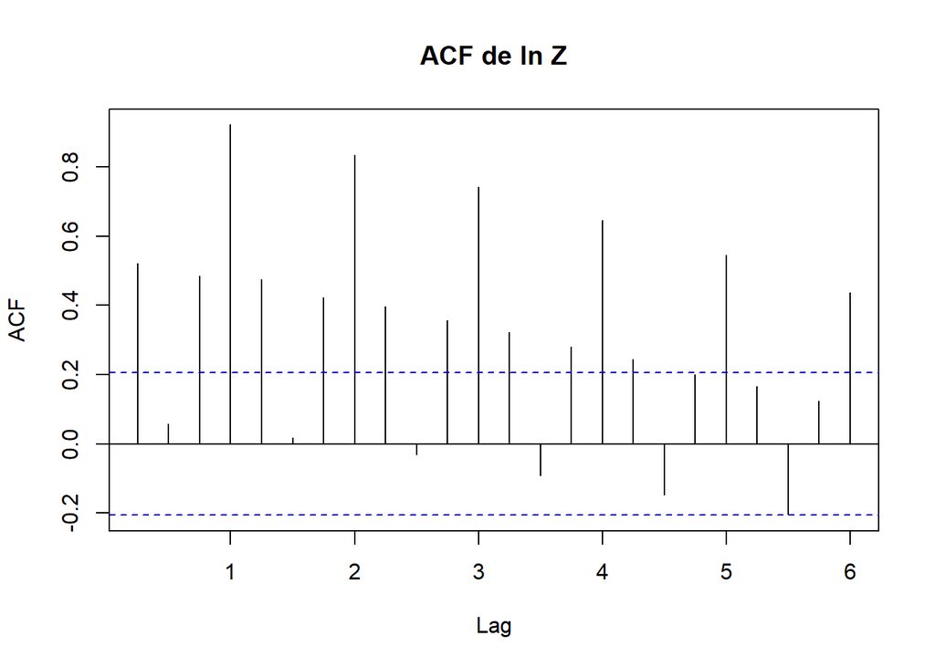

```r
acf(lz,   lag.max = 24, main = "ACF de ln Z")
```

**Mostrar/ocultar código**

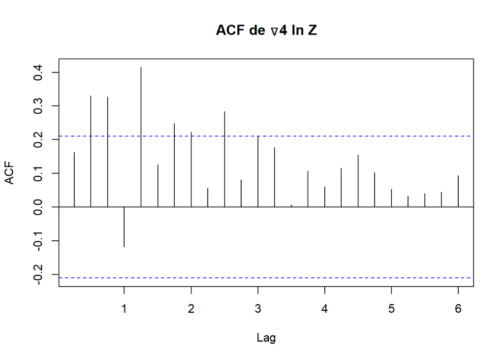

```r
acf(d4lz, lag.max = 24, main = "ACF de ∇4 ln Z")
```

**Mostrar/ocultar código**

```r
# Dickey-Fuller aumentada sobre ∇4 ln Z, tipo deriva

Pmax   <- floor(12 * (length(d4lz) / 100)^(1/4))
adf_d4 <- ur.df(d4lz, type = "drift", lags = Pmax, selectlags = "BIC")
summary(adf_d4)
```

```
###############################################
# Augmented Dickey-Fuller Test Unit Root Test #
###############################################

Test regression drift


Call:
lm(formula = z.diff ~ z.lag.1 + 1 + z.diff.lag)

Residuals:
      Min        1Q    Median        3Q       Max
-0.216669 -0.056838  0.005442  0.050941  0.186334

Coefficients:
             Estimate Std. Error t value Pr(>|t|)
(Intercept)  0.004352   0.010345   0.421 0.675310
z.lag.1     -0.241534   0.152311  -1.586 0.117359
z.diff.lag1 -0.547623   0.156480  -3.500 0.000821 ***
z.diff.lag2 -0.270427   0.163456  -1.654 0.102582
z.diff.lag3 -0.042300   0.151148  -0.280 0.780423
z.diff.lag4 -0.401782   0.113756  -3.532 0.000740 ***
---
Signif. codes:  0 '***' 0.001 '**' 0.01 '*' 0.05 '.' 0.1 ' ' 1

Residual standard error: 0.07339 on 69 degrees of freedom
Multiple R-squared:  0.6781,    Adjusted R-squared:  0.6548
F-statistic: 29.08 on 5 and 69 DF,  p-value: 9.468e-16


Value of test-statistic is: -1.5858 1.4326

Critical values for test statistics:
      1pct  5pct 10pct
tau2 -3.51 -2.89 -2.58
phi1  6.70  4.71  3.86
```

**Mostrar/ocultar código**

```r
adf_d4@lags                       # rezagos aumentados elegidos por BIC
```

```
[1] 11
```

**Mostrar/ocultar código**

```r
adf_d4@teststat                                      # estadístico tau2
```

```
               tau2     phi1
statistic -1.585794 1.432614
```

**Mostrar/ocultar código**

```r
adf_d4@cval                                          # valores críticos
```

```
      1pct  5pct 10pct
tau2 -3.51 -2.89 -2.58
phi1  6.70  4.71  3.86
```

En los rezagos $4, 8$ y $12$, la ACF de $\ln Z_t$ vale $[0.921,\; 0.833,\; 0.742]$ decaw lentamente, mientras que tras aplicar la diferencia estacional $\nabla_4 \ln Z_t$ cae a $[-0.117,\; 0.222,\; 0.209]$, confirmando que $D = 1$.

Prueba Dickey-Fuller para la serie tranformada y diferenciada estacionalmente ($\nabla_4 \ln Z_t$)

$$H_0 : y =0 \ (no \ estacionaria) \; H_1: y < 0 \ (estacionaria)$$

Prueba ADF sobre $\nabla_4 \ln Z_t$ (modelo con deriva): Rezagos aumentados elegidos por BIC: $P = 4$ (observables en z.diff.lag1 a z.diff.lag4 de la regresión) con $P_{\text{máx}} = 11$.

Región de rechazo al 5%: $\tau_2 < -2.89$. Valor observado: $\tau_2 = -1.5858$.

No se rechaza $H_0$ ($-1.5858 > -2.89$).

Como no se rechaza $H_0$, $\nabla_4 \ln Z_t$ todavía presenta una raíz unitaria regular, por lo que es necesaria una diferenciación regular adicional ($d = 1$), pasando a trabajar con $\nabla \nabla_4 \ln Z_t$.

## 3.4 B3

**Mostrar/ocultar código**

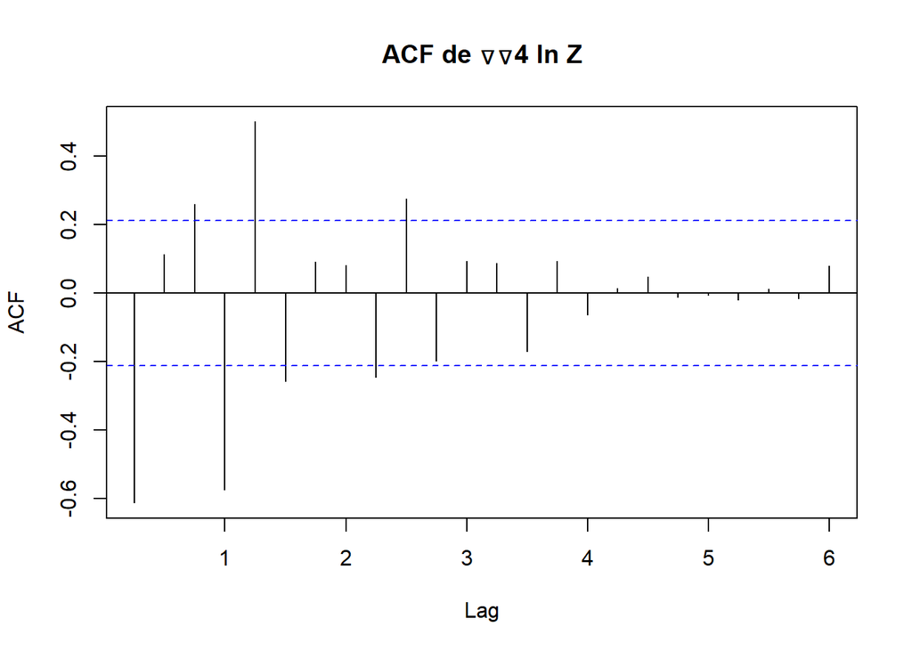

```r
w2 <- diff(diff(lz, lag = 4))           # ∇∇4 ln Z_t


acf(w2,  lag.max = 24, main = "ACF de ∇∇4 ln Z")
```

**Mostrar/ocultar código**

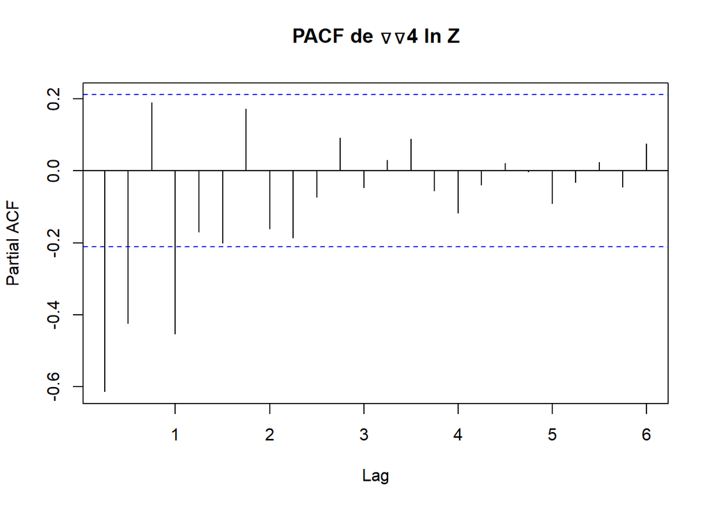

```r
pacf(w2, lag.max = 24, main = "PACF de ∇∇4 ln Z")
```

### 3.4.1 tabla BIC

**Mostrar/ocultar código**

```r
grilla <- expand.grid(p = 0:2, q = 0:2, P = 0:1, Q = 0:1)

tabla_bic <- do.call(rbind, lapply(seq_len(nrow(grilla)), function(i) {
  g   <- grilla[i, ]
  fit <- try(arima(lz, order = c(g$p, 1, g$q),
                   seasonal = list(order = c(g$P, 1, g$Q), period = 4),
                   method = "ML"), silent = TRUE)
  if (inherits(fit, "try-error")) return(NULL)
  data.frame(modelo = sprintf("(%d,1,%d)(%d,1,%d)4", g$p, g$q, g$P, g$Q),
             k = length(coef(fit)), AIC = AIC(fit), BIC = BIC(fit))
}))

tabla_bic <- tabla_bic[order(tabla_bic$BIC), ]
head(tabla_bic, 6)
```

|  | modelo | k | AIC | BIC |
| --- | --- | --- | --- | --- |
| 22 | (0,1,1)(0,1,1)4 | 2 | -198.8960 | -191.5330 |
| 31 | (0,1,1)(1,1,1)4 | 3 | -200.1738 | -190.3564 |
| 25 | (0,1,2)(0,1,1)4 | 3 | -199.7530 | -189.9356 |
| 23 | (1,1,1)(0,1,1)4 | 3 | -199.6330 | -189.8156 |
| 34 | (0,1,2)(1,1,1)4 | 4 | -200.6656 | -188.3939 |
| 21 | (2,1,0)(0,1,1)4 | 3 | -198.0009 | -188.1835 |

El patrón de truncamiento en el rezago 1($-0.613$) de la ACF regular y en el rezago 5($0.501$) de la ACF estacional sugiere un $\text{MA}(1)$ regular y un $\text{MA}(1)$ estacional

La diferencia es de $1.1766$ unidades ($\vert{}-190.3564 - (-191.5330)\vert{}$). Según la escala de Kass y Raftery, al ser menor a 2 unidades, la evidencia no separa ambos modelos, por lo que no se descarta el segundo candidato y ambos avanzan a la etapa de diagnóstico.

## 3.5 B4

### 3.5.1 ajuste

**Mostrar/ocultar código**

```r
m1 <- arima(lz, order = c(0,1,1),
            seasonal = list(order = c(0,1,1), period = 4))

m2 <- arima(lz, order = c(0,1,1),
            seasonal = list(order = c(1,1,1), period = 4))

m1
```

[output not shown]

**Mostrar/ocultar código**

```r
m2
```

[output not shown]

### 3.5.2 Estimacion

**Mostrar/ocultar código**

```r
tabla_t <- function(fit) {
  est <- coef(fit)
  ee  <- sqrt(diag(fit$var.coef))
  data.frame(estimacion = est, ee = ee, t = est / ee)
}
```

### 3.5.3 modelo 1: ARIMA(0,1,1)(0,1,1)

**Mostrar/ocultar código**

```r
tabla_t(m1)
```

|  | estimacion | ee | t |
| --- | --- | --- | --- |
| ma1 | -0.6859596 | 0.07096382 | -9.666329 |
| sma1 | -0.6139842 | 0.08192691 | -7.494292 |

### 3.5.4 modelo 2: ARIMA(0,1,1)(1,1,1)

**Mostrar/ocultar código**

```r
tabla_t(m2)
```

|  | estimacion | ee | t |
| --- | --- | --- | --- |
| ma1 | -0.6728599 | 0.07253003 | -9.276983 |
| sar1 | -0.2960627 | 0.15075229 | -1.963902 |
| sma1 | -0.4474688 | 0.13479653 | -3.319587 |

### 3.5.5 validacion

**Mostrar/ocultar código**

```r
LB <- function(fit, Ks = c(8, 12, 16)) {
  m <- length(coef(fit))                 # no hay constante, porque d + D = 2
  do.call(rbind, lapply(Ks, function(K) {
    b <- Box.test(residuals(fit), lag = K, type = "Ljung-Box", fitdf = m)
    data.frame(K = K, gl = K - m, Q = unname(b$statistic), p_valor = b$p.value)
  }))
}
```

### 3.5.6 lb modelo 1 (m1)

**Mostrar/ocultar código**

```r
LB(m1)
```

| K | gl | Q | p_valor |
| --- | --- | --- | --- |
| 8 | 6 | 12.95717 | 0.04372111 |
| 12 | 10 | 19.91870 | 0.03003113 |
| 16 | 14 | 21.56459 | 0.08801468 |

### 3.5.7 lb modelo 2 (m2)

**Mostrar/ocultar código**

```r
LB(m2)
```

| K | gl | Q | p_valor |
| --- | --- | --- | --- |
| 8 | 5 | 8.009888 | 0.1556915 |
| 12 | 9 | 13.615997 | 0.1366556 |
| 16 | 13 | 15.307370 | 0.2885593 |

### 3.5.8 normalidad m1 y m2

**Mostrar/ocultar código**

```r
shapiro.test(residuals(m1))
```

```
    Shapiro-Wilk normality test

data:  residuals(m1)
W = 0.984, p-value = 0.3297
```

**Mostrar/ocultar código**

```r
shapiro.test(residuals(m2))
```

```
    Shapiro-Wilk normality test

data:  residuals(m2)
W = 0.97708, p-value = 0.1085
```

**Mostrar/ocultar código**

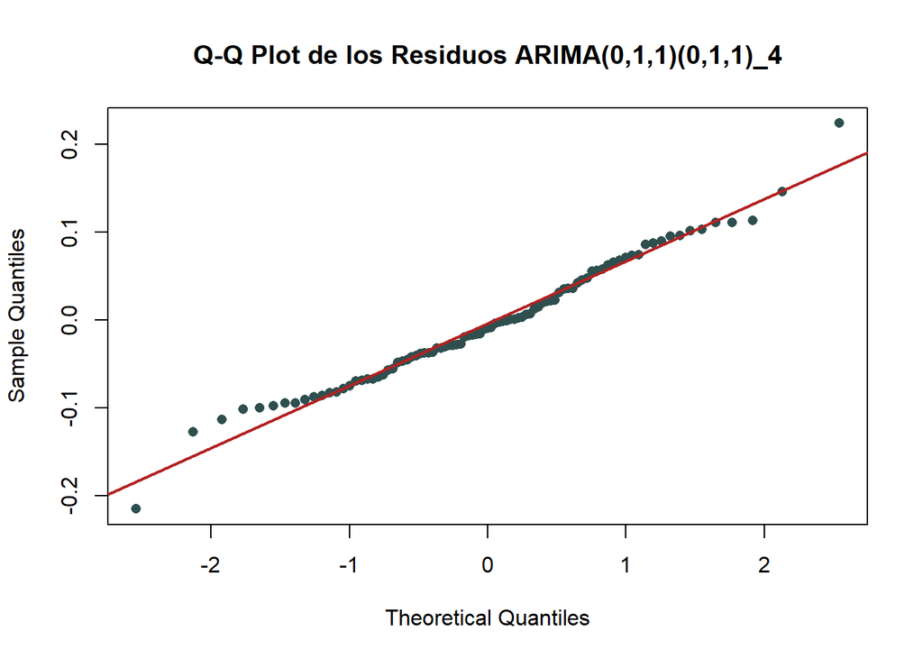

```r
qqnorm(m1$residuals, main = "Q-Q Plot de los Residuos ARIMA(0,1,1)(0,1,1)_4", pch = 16, col = "darkslategray")
qqline(m1$residuals, col = "firebrick", lwd = 2)
```

**Mostrar/ocultar código**

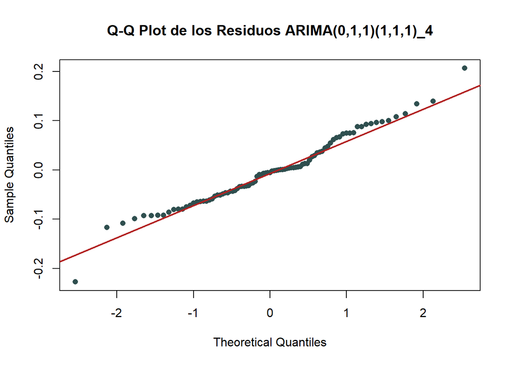

```r
qqnorm(m2$residuals, main = "Q-Q Plot de los Residuos ARIMA(0,1,1)(1,1,1)_4", pch = 16, col = "darkslategray")
qqline(m2$residuals, col = "firebrick", lwd = 2)
```

**Mostrar/ocultar código**

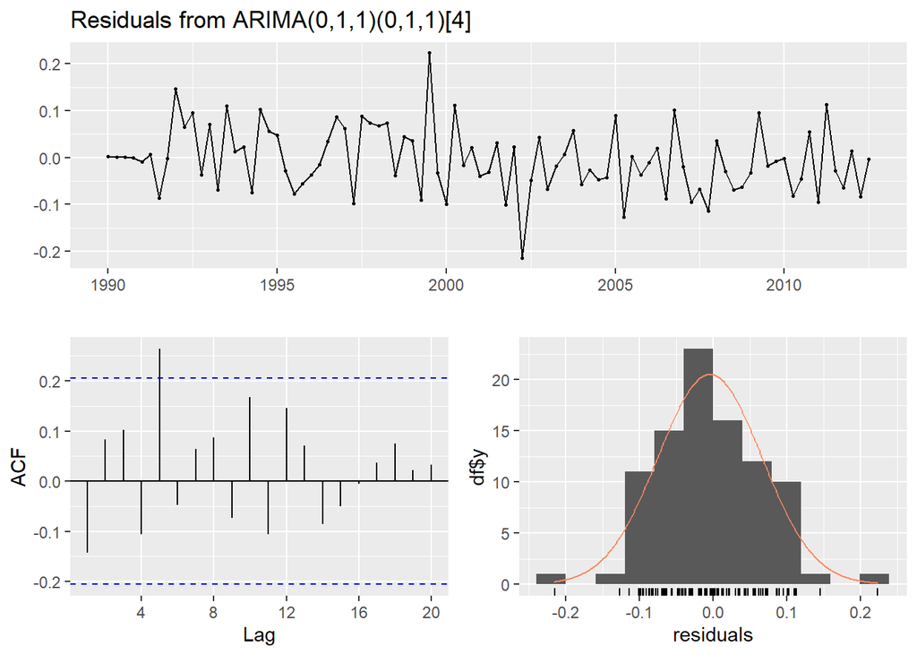

```
    Ljung-Box test

data:  Residuals from ARIMA(0,1,1)(0,1,1)[4]
Q* = 12.957, df = 6, p-value = 0.04372

Model df: 2.   Total lags used: 8
```

```r
checkresiduals(m1)
```

**Mostrar/ocultar código**

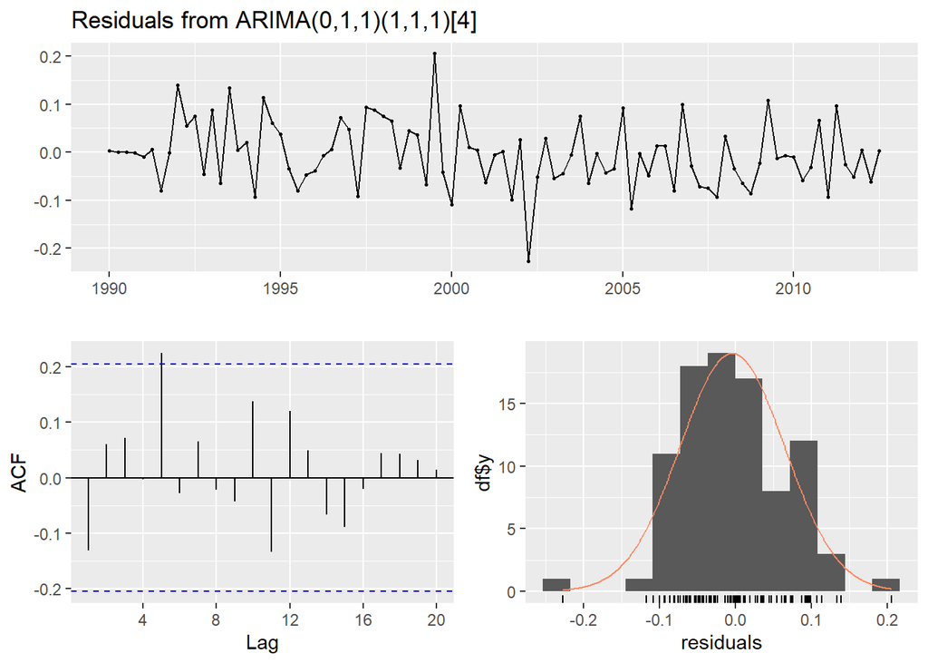

```
    Ljung-Box test

data:  Residuals from ARIMA(0,1,1)(1,1,1)[4]
Q* = 8.0099, df = 5, p-value = 0.1557

Model df: 3.   Total lags used: 8
```

```r
checkresiduals(m2)
```

### 3.5.9 Atipicos

**Mostrar/ocultar código**

```r
at1 <- tso(lz, types = c("AO", "LS", "TC", "IO"),
                  delta = 0.7, cval = 3.5,
                  tsmethod = "arima",
                  args.tsmethod = list(order = c(0,1,1),
                                       seasonal = list(order = c(0,1,1),
                                                       period = 4)))
at1
```

```
Call:
list(method = NULL)

Coefficients:
         ma1     sma1
      -0.686  -0.6140
s.e.   0.071   0.0819

sigma^2 estimated as 0.005231:  log likelihood = 102.45,  aic = -198.9

No outliers were detected.
```

**Mostrar/ocultar código**

```r
at2 <- tso(lz, types = c("AO", "LS", "TC", "IO"), delta = 0.7, cval = 3.5,
                  tsmethod = "arima",
                  args.tsmethod = list(order = c(0,1,1),
                                       seasonal = list(order = c(1,1,1), period = 4)))
at2
```

```
Call:
list(method = NULL)

Coefficients:
          ma1     sar1     sma1
      -0.6729  -0.2961  -0.4475
s.e.   0.0725   0.1508   0.1348

sigma^2 estimated as 0.005015:  log likelihood = 104.09,  aic = -200.17

No outliers were detected.
```

M1 (airline): $\text{ARIMA}(0,1,1)(0,1,1)_4$
$$\nabla \nabla_4 \ln Z_t = (1 - \theta B)(1 - \Theta B^4) a_t$$
con $\hat{\theta} = -\text{ma1} = 0.6860$ y $\hat{\Theta} = -\text{sma1} = 0.6140$ ($\hat{\sigma}^2 = 0.005231$). Estadísticos $t$: $t_{\text{ma1}} = -9.67$ y $t_{\text{sma1}} = -7.49$; ambos son altamente significativos ($\vert{}t\vert{} > 2$).

M2: $\text{ARIMA}(0,1,1)(1,1,1)_4$
$$(1 - \Phi B^4)\nabla \nabla_4 \ln Z_t = (1 - \theta B)(1 - \Theta B^4) a_t$$
con $\hat{\Phi} = \text{sar1} = -0.2961$, $\hat{\theta} = -\text{ma1} = 0.6729$ y $\hat{\Theta} = -\text{sma1} = 0.4475$ ($\hat{\sigma}^2 = 0.005015$). Estadísticos $t$: $t_{\text{ma1}} = -9.28$, $t_{\text{sar1}} = -1.964$ y $t_{\text{sma1}} = -3.32$.Prueba de Ljung-Box: Con $m = 2$ en M1 ($gl = K - 2$) y $m = 3$ en M2 ($gl = K - 3$)

Al 5% de significancia, M1 presenta autocorrelación residual en los rezagos $K = 8$ y $K = 12$ ($p < 0.05$), por lo que no cumple el supuesto de ruido blanco. En contraste, M2 no muestra autocorrelación residual en ninguno de los rezagos evaluados (todos los $p > 0.05$).

Normalidad (Shapiro-Wilk): En ambos modelos no se rechaza la normalidad de los residuales al 5% (M1: $W = 0.9840$, $p = 0.3297$; M2: $W = 0.9771$, $p = 0.1085$).

No se detectó ningún valor atípico en ninguno de los dos modelos. En M2, el parámetro $\text{sar1}$ tiene $\vert{}t\vert{} = 1.964 < 2$, ubicándose justo en el límite de la significancia individual al 5% ($1.96$). Sin embargo, no conviene eliminarlo, ya que prescindir de él reduce el modelo a M1, el cual falla la prueba de ruido blanco de Ljung-Box y presenta mayor varianza residual

## 3.6 B5

**Mostrar/ocultar código**

```r
ltr   <- log(train)
m1_tr <- arima(ltr, order = c(0,1,1), seasonal = list(order = c(0,1,1), period = 4))   # M1
m2_tr <- arima(ltr, order = c(0,1,1), seasonal = list(order = c(1,1,1), period = 4))   # M2

p1 <- predict(m1_tr, n.ahead = h)
p2 <- predict(m2_tr, n.ahead = h)

sn <- snaive(train, h = h)$mean    # ingenuo estacional (escala original)

hw <- predict(HoltWinters(train, seasonal = "multiplicative"),
              n.ahead = h)         # Holt-Winters multiplicativo

pron <- data.frame(
  real       = as.numeric(test),
  M1_mediana = exp(p1$pred),            # mediana en escala original
  M1_media   = exp(p1$pred + p1$se^2 / 2), # media retransformada:
  M2_mediana = exp(p2$pred),
  ing_estac  = as.numeric(sn),
  HW_mult    = as.numeric(hw)
)

# RMSE, MAPE y MASE. Escala del MASE: MAE del ingenuo estacional en entrenamiento
escala <- mean(abs(diff(train, lag = 4)))

metricas <- function(f) {
  e <- pron$real - f
  c(RMSE = sqrt(mean(e^2)),
    MAPE = 100 * mean(abs(e) / pron$real),
    MASE = mean(abs(e)) / escala)
}

tabla_val <- sapply(pron[, -1], metricas)
round(t(tabla_val), 2)
```

```
            RMSE MAPE MASE
M1_mediana  8.34 4.36 0.68
M1_media    8.54 4.67 0.73
M2_mediana  8.15 3.92 0.63
ing_estac  14.27 7.32 1.17
HW_mult     7.61 3.39 0.54
```

**Mostrar/ocultar código**

```r
# Ganador por RMSE y brecha con el segundo lugar
rmse_ord <- sort(tabla_val["RMSE", ])
rmse_ord
```

```
   HW_mult M2_mediana M1_mediana   M1_media  ing_estac
  7.609365   8.154242   8.338035   8.540824  14.265928
```

**Mostrar/ocultar código**

```r
round(diff(rmse_ord[1:2]), 2)
```

```
M2_mediana
      0.54
```

Con la validación 2010-T4 a 2012-T3 (h = 8), Holt-Winters multiplicativo tiene el menor error en las tres métricas (RMSE = 7.61; MAPE = 3.39 %; MASE = 0.54). Le siguen M2 mediana (RMSE = 8.15; MAPE = 3.92 %; MASE = 0.63), M1 mediana (8.34; 4.36 %; 0.68), M1 media (8.54; 4.67 %; 0.73) y el ingenuo estacional (14.27; 7.32 %; 1.17). El ingenuo estacional es el peor, con un MASE de 1.17, lo que confirma que los modelos aprovechan mejor la estructura de la serie. Entre los dos ARIMA, M2 supera a M1 con la mediana, en línea con lo que se concluyó anteriormente.

Como la transformación exponencial es convexa, la distribución en escala original tiene cola a la derecha y su media supera a su mediana en el factor exp(v̂/2). Este factor crece con el horizonte, porque v̂ aumenta con h. Si el modelo es correcto, la media es el pronóstico de menor MSE en escala original, porque es el valor esperado condicional, mientras que la mediana minimiza el error absoluto. En esta validación, sin embargo, M1 media (RMSE = 8.54) fue peor que M1 mediana (8.34): con solo 8 observaciones, esa diferencia es variabilidad muestral y no contradice la teoría

Holt-Winters multiplicativo es el método con mejor desempeño en validación, con RMSE = 7.61 frente a 8.15 de M2 mediana ($\text{ARIMA}(0,1,1)(1,1,1)_4$), que es el segundo. La diferencia es de 0.54 miles de visitantes por trimestre, es decir, unos 540 viajeros. Frente a un nivel de la serie que en el periodo de validación oscila entre ~90 y ~200 mil visitantes, la brecha es pequeña y no justifica por sí sola descartar el modelo ARIMA.

## 3.7 B6

**Mostrar/ocultar código**

```r
fin <- arima(lz, order = c(0,1,1),
             seasonal = list(order = c(1,1,1), period = 4))   # M2, elegido en B4 y B5
pf  <- predict(fin, n.ahead = 8)   # h = 1 es 2012-T4; h = 8 es 2014-T3

tab_final <- data.frame(
  trimestre = c("2012-T4", "2013-T1", "2013-T2", "2013-T3",
                "2013-T4", "2014-T1", "2014-T2", "2014-T3"),
  h       = 1:8,
  mediana = round(exp(pf$pred), 2),
  li95    = round(exp(pf$pred - 1.96 * pf$se), 2),
  ls95    = round(exp(pf$pred + 1.96 * pf$se), 2),
  media   = round(exp(pf$pred + pf$se^2 / 2), 2)       # media retransformada
)




total_2013 <- sum(tab_final$media[2:5])
total_2011 <- sum(window(serie_ts_B, start = c(2011, 1), end = c(2011, 4)))
```

**Mostrar/ocultar código**

```r
tab_final
```

| trimestre | h | mediana | li95 | ls95 | media |
| --- | --- | --- | --- | --- | --- |
| 2012-T4 | 1 | 200.23 | 174.28 | 230.04 | 200.73 |
| 2013-T1 | 2 | 181.70 | 157.01 | 210.27 | 182.20 |
| 2013-T2 | 3 | 94.80 | 81.36 | 110.47 | 95.09 |
| 2013-T3 | 4 | 98.16 | 83.68 | 115.13 | 98.48 |
| 2013-T4 | 5 | 191.09 | 159.79 | 228.53 | 191.89 |
| 2014-T1 | 6 | 176.45 | 146.24 | 212.90 | 177.26 |
| 2014-T2 | 7 | 89.69 | 73.71 | 109.14 | 90.14 |
| 2014-T3 | 8 | 94.38 | 76.93 | 115.79 | 94.90 |

**Mostrar/ocultar código**

```r
c(total_2013   = total_2013,
  total_2011   = total_2011,
  variacion_pct = 100 * (total_2013 - total_2011) / total_2011)
```

```
   total_2013    total_2011 variacion_pct
   567.660000    608.101000     -6.650376
```

**Mostrar/ocultar código**

```r
tab_final[c(1, 8), ]
```

|  | trimestre | h | mediana | li95 | ls95 | media |
| --- | --- | --- | --- | --- | --- | --- |
| 1 | 2012-T4 | 1 | 200.23 | 174.28 | 230.04 | 200.73 |
| 8 | 2014-T3 | 8 | 94.38 | 76.93 | 115.79 | 94.90 |

El modelo ajustado con toda la serie pronostica para 2012-T4 una mediana de 200.2 mil visitantes, con IC 95 % [174.3; 230.0] (media 200.7). Para 2014-T3 pronostica 94.4 mil, con IC 95 % [76.9; 115.8] (media 94.9). En escala original, el intervalo de 2012-T4 es más ancho en unidades absolutas, pero en términos relativos es más amplio en 2014-T3 (±21 % frente a ±14 %), porque la incertidumbre en escala logarítmica crece con el horizonte.

La suma de las medias de 2013 (2013-T1 a 2013-T4) es 567.67 miles de visitantes, frente a 608.10 miles observados en 2011. Esto representa una disminución esperada de 40.43 miles, equivalente a −6.6 %. Como es un pronóstico puntual con intervalos amplios por trimestre, siendo una tendencia moderada a la baja y no es un valor exacto.

### 3.7.1 mensaje

Para el verano austral de 2012-2013 (2012-T4 y 2013-T1) el modelo prevé unos 200 mil y 182 mil visitantes respectivamente, pero el intervalo de 95 % es amplio (de 174 a 230 mil en 2012-T4) y (de 157 a 210 mil en 2013-T1), por lo que la capacidad debe planearse para almenos 230 mil viajeron en el trimestre 2012-T4 y reduzcan su capacidad hasta 210 mil pasajeros en el trimestre 2013-T1. Para los siguientes trimestres se espera que se reduzcan los viajeros en cada trimestre a comparacion de años anteriores. Se recomienda hacer un estudio frecuente para dar cifras mas precisas

El riesgo de Planear la capacidad con la media en lugar de la mediana es debido a que eleva el pronóstico solo unos 0.5 mil visitantes por trimestre, ademas la media esta sujeta a valores extremos presentes mientras que la mediana no haciendola mas estable.

# 4 Uso de IA

Para la elaboración de este trabajo se utilizó ChatGPT y Claude como herramientas de apoyo. Su uso se limitó a:

- Apoyar la comprensión e interpretación de la *prueba HEGY* y sus resultados.
- Ayudar a identificar y corregir *errores en el código de R y Quarto* durante la elaboración del análisis.
- Sugerir mejoras en la *redacción e interpretación* de algunos resultados.
- Apoyar la organización y presentación de tablas y resultados.
- Sugerir ajustes en los *colores, títulos y formato de las gráficas* para mejorar su presentación.
- Revisar la sintaxis de algunos fragmentos de código y proponer alternativas más sencillas.

Los análisis, decisiones sobre los modelos y resultados presentados fueron revisados por el equipo y corresponden a los procedimientos desarrollados para el trabajo.